# Kurva Aljabar - Unit 1-24

Dua puluh empat kuliah dan lembar kerja pertama, edisi Bahasa Indonesia

Holger Brenner (karya sumber)

2026-08-25

# Tentang edisi ini

Ini adalah checkpoint parsial kumulatif dan koheren dari edisi kerja Bahasa Indonesia yang independen atas materi *Algebraische Kurven* karya Holger Brenner. Pembaca ini memuat dua puluh empat kuliah beserta dua puluh empat lembar kerja, tetapi sumbernya terdiri atas dua batas mata kuliah yang berbeda. Unit 1-23 mengikat revisi beku *Algebraische Kurven (Osnabrück 2025-2026)*. Pada batas sumber yang dibekukan, mata kuliah 2025-2026 tidak mempunyai Unit 24. Karena itu, Unit 24 mengikat kuliah dan lembar kerja resmi dari mata kuliah lengkap yang lebih lama, *Algebraische Kurven (Osnabrück 2012)*. Unit 24 bukan Unit 24 dari edisi 2025-2026, dan kedua mata kuliah tersebut tidak diperlakukan sebagai satu edisi sumber.

Penerjemahan, pemeriksaan, dan produksi edisi dibantu oleh alat berikut: **OpenAI Codex gpt-5.6-sol, Ultra.** Pekerjaan dilakukan atas arahan pengguna. Edisi ini bukan terbitan resmi Universitas Osnabrück, Holger Brenner, Wikiversity, OpenAI, atau Wikimedia Foundation, dan tidak menyiratkan dukungan dari pihak-pihak tersebut.

Teks kuliah sumber dibuat oleh Holger Brenner (nama pengguna Wikiversity: Bocardodarapti). Materi sumber Unit 1-23 dinyatakan berlisensi [Creative Commons Attribution-ShareAlike 4.0 International](https://creativecommons.org/licenses/by-sa/4.0/). Unit 24 mempertahankan rantai hak yang tercatat untuk komponen sumber 2012-nya, termasuk pernyataan lama [Creative Commons Attribution-ShareAlike 2.0 Germany](https://creativecommons.org/licenses/by-sa/2.0/de/) dan pernyataan CC BY-SA 4.0 yang berlaku pada komponen yang dibekukan. Teks terjemahan edisi ini dibagikan dengan CC BY-SA 4.0 sesuai kewajiban atribusi dan ShareAlike; pernyataan itu tidak mengganti atau menghapus lisensi komponen sumber.

Edisi ini menerjemahkan dan menata ulang materi sumber; perubahan bahasa, penataan, koreksi yang diungkapkan, dan jembatan edisi dilakukan pada 2026. Revisi sumber, hash, hubungan setiap unit, setiap koreksi matematis, dan setiap tambahan penghubung dicatat dalam berkas kontrol dan backend yang menyertai edisi. Identitas model di atas adalah catatan provenans alat dan tidak menggantikan kredit penulis sumber atau kontribusi manusia.

Gambar-gambar dari Wikimedia Commons dan Wikiversity serta PDF resmi hulu tidak menerima lisensi tunggal dari pernyataan lisensi teks terjemahan. Setiap komponen mempertahankan pencipta, sumber, dan lisensinya sendiri sebagaimana tercatat dalam `authority/RIGHTS.csv`, berkas hak dan penutupan aset per unit yang berlaku, serta bagian kredit media pada akhir pembaca. Pembaca ini adalah himpunan berlisensi campuran, bukan klaim lisensi payung atas semua komponen.

Versi teks yang mengikat untuk setiap unit ialah revisi Wikiversity yang tercantum dalam authority freeze unit tersebut. Untuk tiga unit baru pada checkpoint ini: Unit 22 mengikat Kuliah 22 revisi 1051397 dan Lembar Kerja 22 revisi 1062660; Unit 23 mengikat Kuliah 23 revisi 1112318 dan Lembar Kerja 23 revisi 1062659. Unit 24 mengikat `Kurs:Algebraische Kurven (Osnabrück 2012)/Vorlesung 24`, halaman 50730, revisi 933672, dan `Kurs:Algebraische Kurven (Osnabrück 2012)/Arbeitsblatt 24`, halaman 50759, revisi 793492. PDF resmi setiap unit dibekukan sebagai saksi visual/build; PDF yang lebih tua daripada revisi tekstual terakhir bukan otoritas tekstual pengganti.

# Cara memakai edisi ini

Baca setiap kuliah lalu kerjakan lembar kerja dengan nomor yang sama. Unit 1-24 memuat 622 soal. Tanda bintang mengikuti sumber dan menunjukkan soal yang mempunyai halaman solusi publik pada batas sumber yang dibekukan. Edisi ini menerjemahkan semua 114 solusi publik yang dibekukan tersebut; tidak ada solusi baru yang diada-adakan. Rumus, penomoran, nilai soal, petunjuk, dan urutan unit dipertahankan agar edisi dapat diperiksa terhadap revisi sumber masing-masing.

Catatan edisi menandai secara terbuka setiap koreksi atas kekeliruan atau kekurangan sumber yang akan menyesatkan pembaca. Tambahan yang diperlukan untuk menjembatani langkah pembuktian atau prasyarat selalu diberi label `Jembatan edisi`; tambahan tersebut bukan bagian dari teks sumber dan tidak diatribusikan kepada penulis sumber.

# Kuliah 1: Kurva Aljabar Bidang

## Kurva aljabar bidang

Apakah kurva aljabar itu? Misalnya, objek-objek yang tampak pada gambar-gambar indah berikut.

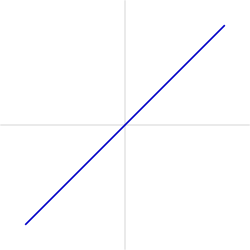

Grafik fungsi linear

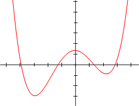

Grafik polinom berderajat empat

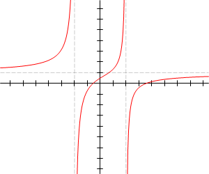

Grafik fungsi rasional

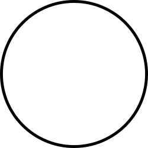

Lingkaran satuan

[figure not shown]

Elips

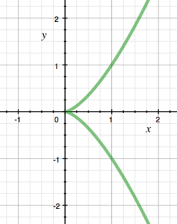

Kurva dengan kuspa

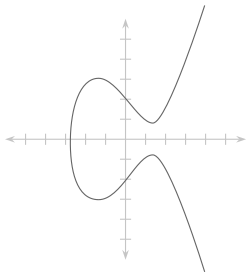

Contoh kurva eliptik

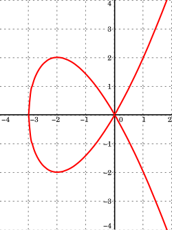

Kubik Tschirnhausen

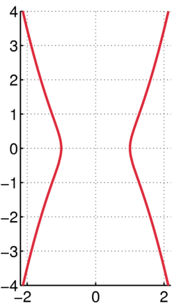

Kampyle Eudoxus

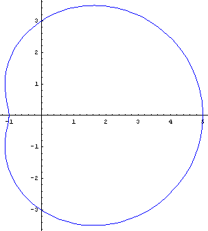

Konkoid Pascal

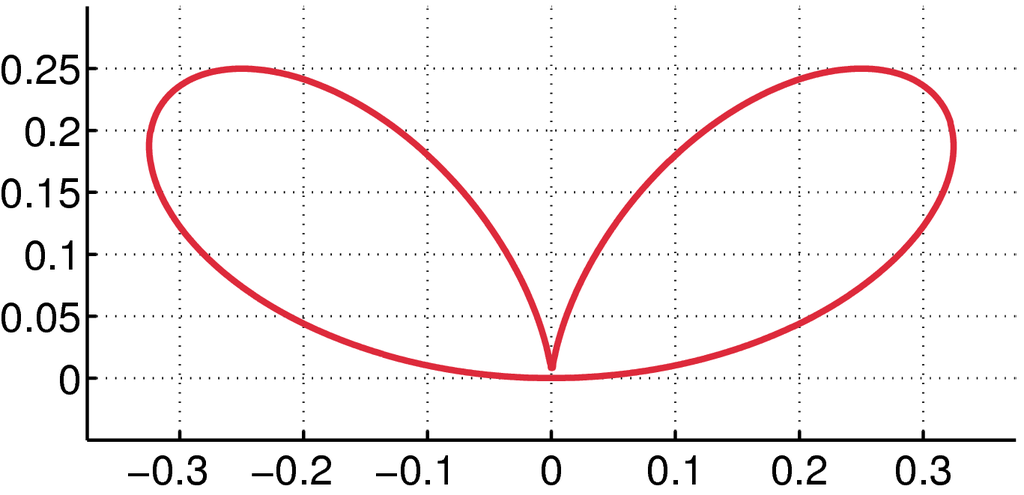

Bifolium

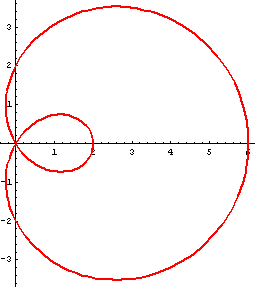

Limaçon

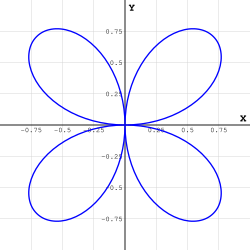

Quadrifolium

Tentu saja kita dapat menggambar banyak hal. Kurva-kurva berikut juga indah, tetapi bukan kurva aljabar.

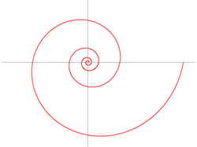

Spiral logaritmik

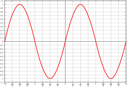

Grafik sinus

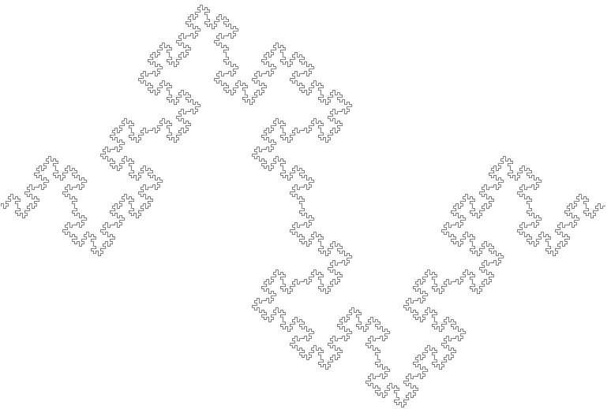

Kurva Koch kuadratik

Kata “aljabar” dalam *kurva aljabar* berasal dari pembatasan bahwa definisinya hanya boleh menggunakan operasi aljabar, yakni penjumlahan dan perkalian, bukan proses analitis seperti mengambil limit, membentuk jumlah tak hingga, melakukan hampiran, mendiferensialkan, atau mengintegralkan. Pemetaan yang diizinkan dalam konteks kita diberikan oleh polinom dalam beberapa variabel. Gambar-gambar di atas menampilkan kurva aljabar bidang yang didefinisikan oleh sebuah polinom dalam dua variabel. Dua gambar pertama adalah *grafik* suatu fungsi polinomial dalam satu variabel; keduanya dideskripsikan oleh

$$Y=P(X).$$

Pada gambar pertama, $P(X)=X$ (jadi polinomnya linear), sedangkan pada gambar kedua bentuknya kurang lebih

$$P(X)=a_4X^4+a_3X^3+a_2X^2+a_1X+a_0,$$

dengan koefisien-koefisien $a_i$ dalam suatu lapangan $K$. Dalam geometri aljabar kita menetapkan sebuah *lapangan dasar* $K$. Lapangan penting bagi kita adalah bilangan real (gambar-gambar tadi terutama harus dipahami dalam arti ini) dan bilangan kompleks $\mathbb C$. Grafik semacam itu merupakan objek yang sederhana dalam arti bahwa setiap nilai $X$ memiliki tepat satu nilai $Y$, yaitu nilai fungsi, dan nilai itu mudah dihitung apabila kita dapat berhitung di lapangan yang diberikan. Dalam arti tertentu, grafik tersebut adalah salinan “melengkung” dari garis dasar, yakni sumbu $X$.

Sekarang perhatikan gambar ketiga. Gambar itu adalah grafik suatu *fungsi rasional*: kita mengambil dua polinom $P,Q$ dalam variabel $X$, lalu meninjau hasil bagi $P(X)/Q(X)$. Ungkapan ini hanya bermakna ketika penyebutnya tidak nol. Pada akar-akar polinom penyebut, fungsi rasional tidak terdefinisi. Jika pembilang dan penyebut sama-sama nol di suatu titik, kadang-kadang penyederhanaan pecahan membuat hasil bagi itu dapat diberi makna di titik tersebut. Jika penyebut nol tetapi pembilang tidak, titik ketakterdefinisian itu merupakan sebuah *kutub*: grafik real mendekati $+\infty$ atau $-\infty$. Memang menggoda untuk mengatakan bahwa nilai fungsi rasional pada titik-titik itu adalah “tak hingga”; dalam geometri projektif gagasan ini benar-benar bermakna, sebagaimana akan kita lihat nanti.

Namun, “persamaan grafik” $Y=P(X)/Q(X)$ bukan deskripsi yang ideal karena adanya titik-titik ketakterdefinisian. Jika persamaan itu dikalikan dengan penyebutnya, kita memperoleh syarat, atau *persamaan*,

$$YQ(X)=P(X),
\qquad\text{atau lebih tepatnya}\qquad
\{(x,y)\in K^2\mid yQ(x)=P(x)\},$$

yang kedua ruasnya berupa polinom yang terdefinisi dengan baik. *Himpunan pemenuh* (atau *himpunan solusi*) terdefinisi secara tunggal. Untuk suatu $x$ dengan $Q(x)=0$, ruas kiri bernilai nol. Jika $P(x)\ne0$, tidak ada solusi pada $x$ itu, seperti pada gambar; jika $P(x)=0$, setiap nilai $Y$ diperbolehkan. Dalam kasus terakhir, objek tersebut memuat garis melalui $(x,0)$ yang tegak lurus terhadap sumbu $X$.

### Contoh: hiperbola

Contoh khas dan penting dari fungsi rasional adalah $Y=1/X$. Grafik yang bersesuaian disebut *hiperbola* $H$. Tanpa penyebut, persamaannya menjadi

$$XY=1,
\qquad\text{atau}\qquad
H=\{(x,y)\mid xy=1\}.$$

Pada $K^\times=K\setminus\{0\}$, fungsi rasional ini merupakan fungsi sejati, dengan $H$ sebagai grafiknya, dan memberikan bijeksi “alami”

$$K^\times\longrightarrow H,
\qquad x\longmapsto\left(x,\frac1x\right).$$

Jadi, dalam pengertian yang akan dibuat presisi nanti, $K^\times$ dan $H$ “ekuivalen” atau “isomorfik”.

Kedua deskripsi tersebut memiliki kelebihan masing-masing. Deskripsi sebagai $K^\times\subset K$ berlangsung pada sebuah garis (jika kita membayangkan $K=\mathbb R$), tetapi titik $0$, yang merupakan *titik limit* dari $K^\times$, tidak termasuk dalam $K^\times$. Dengan kata lain, $K^\times$ tidak *tertutup*. Sebaliknya, hiperbola tertutup di $\mathbb R^2$; jadi, untuk mewujudkannya sebagai himpunan tertutup, kita harus berpindah ke dimensi yang lebih tinggi. Pertanyaan mengenai deskripsi yang baik bagi sebuah objek geometri aljabar akan terus muncul.

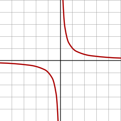

Hiperbola siku-siku

Dalam kasus real, yakni $K=\mathbb R$, himpunan $\mathbb R^\times$ (dan demikian pula $H_{\mathbb R}$) terdiri atas dua “cabang” yang saling lepas, sehingga tidak *terhubung*. Dalam kasus kompleks, yakni $K=\mathbb C$, himpunan $\mathbb C^\times$ (dan demikian pula $H_{\mathbb C}$) adalah bidang real dengan satu titik dihilangkan, sehingga terhubung. Ini adalah fenomena khas geometri aljabar: sifat-sifat penting dapat bergantung pada lapangan dasar. Meskipun demikian, sifat-sifat yang hanya bergantung pada persamaan yang mendeskripsikan objek—dan berlaku bagi himpunan solusi di atas semua lapangan—mempunyai arti yang sangat khusus.

Gambar keempat adalah sebuah *lingkaran*, dengan persamaan

$$K=\{(x,y)\mid x^2+y^2=r^2\},$$

di mana $r$ menyatakan jari-jari lingkaran. Gambar itu sendiri sudah menunjukkan bahwa objek ini tidak mungkin merupakan grafik sebuah fungsi, sebab pada suatu grafik setiap nilai $x$ selalu berpasangan dengan tepat satu nilai $y$. Tidak ada fungsi $y=\varphi(x)$ yang memenuhi

$$K=\{(x,\varphi(x))\mid x\in\mathbb R\}.$$

Pertanyaan apakah suatu objek solusi aljabar dapat diwujudkan sebagai grafik ekuivalen dengan pertanyaan apakah persamaan pendefinisinya dapat “diselesaikan” terhadap $y$. Pada contoh ini kita dapat menulis

$$y^2=r^2-x^2,
\qquad
y=\sqrt{r^2-x^2}=\sqrt{(r-x)(r+x)}.$$

Jadi, apakah lingkaran itu ternyata sebuah grafik? Ada dua penafsiran.

1. Jika kita membatasi diri pada bilangan real dan akar positif, langkah terakhir bukan transformasi yang ekuivalen: kita telah “menambahkan” informasi yang tidak ada dalam persamaan semula. Mengambil akar positif berarti membatasi diri pada setengah lingkaran atas. Menambahkan informasi atau syarat memperkecil himpunan solusi.
2. Jika sebaliknya $\sqrt{\phantom{x}}$ dipahami sebagai semua solusi—dalam bilangan real, akar kuadrat positif dan negatif, yang sering ditulis $\pm\sqrt{\phantom{x}}$—kita tidak menambahkan informasi, tetapi juga belum menyelesaikan persamaan menjadi sebuah fungsi; kita baru memperoleh apa yang kadang disebut “fungsi bernilai banyak”.

Kedua sudut pandang itu berguna. Upaya mencari deskripsi sederhana sebagai grafik bagi suatu bagian objek geometri, seperti busur atas, muncul kembali dalam teorema fungsi implisit, pendekatan deret pangkat, parametrisasi, dan teori lokal.

## Persamaan berbentuk $Y^2=G(X)$

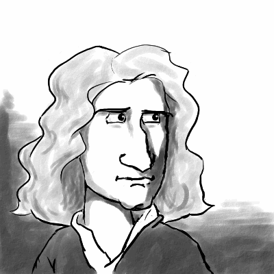

[figure not shown]

Isaac Newton (1643–1727)

Persamaan lingkaran dapat dipandang sebagai persamaan berbentuk

$$Y^2=G(X),$$

dengan $G$ sebuah polinom dalam satu variabel $X$; untuk lingkaran, $G=-X^2+1$. Objek ini bukan grafik, melainkan “akar” dari sebuah grafik. Secara umum, izinkan $G(X)$ lebih rumit. Himpunan nol (*lokus nol*) tersebut merepresentasikan akar kuadrat $\sqrt{G(X)}$. Jika kita menetapkan sebarang nilai $x$ bagi $X$, maka dalam bilangan real ada tiga kemungkinan bagi solusi $y$ yang bersesuaian.

1. Jika $G(x)<0$, tidak ada solusi.
2. Jika $G(x)=0$, terdapat tepat satu solusi, yaitu $y=0$.
3. Jika $G(x)>0$, terdapat dua solusi, yaitu $y=\pm\sqrt{G(x)}$.

Ini juga memberi cara untuk membayangkan gambar realnya: untuk setiap $x$, hitung $G(x)$, lalu—jika radikannya taknegatif—tandai titik-titik $(x,\pm\sqrt{G(x)})$.

Di atas bilangan kompleks, kita hanya perlu membedakan kasus $G(x)=0$ dan $G(x)\ne0$. Jika $G$ berderajat dua, kurva yang diperoleh merupakan sebuah *irisan kerucut*, yang telah dipelajari sejak zaman kuno (lihat Kuliah 7).

Isaac Newton mempelajari secara intensif kasus ketika $G(X)$ adalah polinom kubik real, yaitu berderajat tiga. Bahkan bahan contoh ini saja sudah sangat kaya.

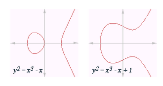

Contoh-contoh kurva eliptik real

Perhatikan kasus $G(X)=X^3$, yaitu objek yang dideskripsikan oleh

$$\{(x,y)\mid y^2=x^3\}.$$

Objek ini disebut *parabola Neil*. Di sini muncul fenomena baru: titik asal berbeda dari semua titik lainnya. Kita menyebutnya sebuah *singularitas*; sebaliknya, titik-titik lain disebut *mulus* atau *nonsingular*. Memberikan definisi yang tepat merupakan bagian dari mata kuliah ini. Sebagai rumusan awal yang belum presisi, sebuah kurva di sekitar titik mulus, setelah memilih koordinat yang sesuai, tampak seperti grafik—yang mungkin telah diputar—dari suatu fungsi terdiferensialkan. Singularitas pada parabola Neil juga disebut *titik runcing* atau *kuspa* (kata *cusp* sendiri berarti titik runcing). Sebaliknya, singularitas pada gambar ke-8 adalah *titik perpotongan* atau *titik ganda*.

Pada gambar ke-7 di bagian awal, dan juga pada gambar di atas, kita melihat himpunan nol berbentuk $Y^2=G(X)$ dengan $G(X)$ berderajat tiga. Seperti apakah $G(X)$ agar menghasilkan kurva semacam itu? Contoh-contoh terakhir juga menunjukkan bahwa keberadaan singularitas bergantung pada bentuk tepat $G(X)$.

Mari kita tetap meninjau parabola Neil $C$. Jika $t$ adalah sebarang bilangan real atau kompleks, titik dengan koordinat

$$(x,y)=(t^2,t^3)$$

selalu terletak pada parabola Neil, karena $(t^2)^3=t^6=(t^3)^2$. Sebaliknya, dapat pula dibuktikan (lihat [Soal 1.6](https://de.wikiversity.org/wiki/Neilsche_Parabel/Bildbeschreibung_durch_Gleichung/Aufgabe)) bahwa setiap titik pada parabola Neil berbentuk demikian: untuk setiap $(x,y)$ dengan $y^2=x^3$, ada tepat satu $t$ dengan $(x,y)=(t^2,t^3)$. Pemetaan

$$\mathbb R\longrightarrow C,
\qquad t\longmapsto(t^2,t^3),$$

disebut *parametrisasi* (polinomial bijektif) dari parabola Neil. Menentukan kurva aljabar mana yang mempunyai parametrisasi polinomial merupakan pertanyaan taktrivial. Kurva mulus berbentuk $Y^2=G(X)$ dengan $\deg G=3$ tidak mempunyai parametrisasi semacam itu. Dalam teori bilangan elementer, kita mempelajari bahwa semua *tripel Pythagoras* dapat ditulis dalam bentuk sederhana yang seragam; lihat [Teorema 10.6 (Teori Bilangan, Osnabrück 2025)](https://de.wikiversity.org/wiki/Pythagoreische_Tripel/Parametrische_Charakterisierung/Fakt). Pernyataan yang ekuivalen adalah adanya parametrisasi rasional lingkaran satuan rasional; lihat [Teorema 10.4](https://de.wikiversity.org/wiki/Einheitskreis/Rationale_Parametrisierung/Fakt). Kita akan membahas hal ini dengan generalitas yang lebih besar dalam [Teorema 7.6](https://de.wikiversity.org/wiki/Quadrik_in_zwei_Variablen/Rationale_Parametrisierung/Fakt).

Sekarang kita sampai pada definisi umum pertama.

### Definisi: kurva aljabar bidang afin

Misalkan $K$ suatu lapangan. Sebuah *kurva aljabar bidang afin* di atas $K$ adalah himpunan nol (*lokus nol*) $V(F)\subseteq K^2$ dari suatu polinom takkonstan $F$ dalam dua variabel, yaitu

$$F=\sum_{0\le i,j\le m}a_{ij}X^iY^j
\qquad (a_{ij}\in K).$$

Dengan kata lain,

$$V(F)=\left\{(x,y)\in K^2\;\middle|\;
F(x,y)=\sum_{0\le i,j\le m}a_{ij}x^iy^j=0\right\}.$$

Polinom-polinom favorit dalam variabel $X$ dan $Y$ yang disebutkan di kelas adalah:

1. $X^2-Y^2$;
2. $2X+4Y+3$;
3. $X^2+Y^2-3$;
4. $X^2+Y^2$;
5. $5X^2+12Y^2-26$;
6. $3X^2-15Y^2-3$;
7. $X^3+Y^3+XY$;
8. $X^3-4Y^2-XY$;
9. $X^4$;
10. $X^2Y^2-X^2$.

Tingkat kesulitan memahami himpunan nol $V(F)$ yang bersesuaian berbeda-beda. Dengan identitas selisih dua kuadrat,

$$X^2-Y^2=(X+Y)(X-Y),$$

dan karena hasil kali dua unsur dalam suatu lapangan sama dengan nol tepat ketika salah satu faktornya nol, lokus nol ini hanyalah gabungan diagonal utama dan diagonal lainnya: gabungan dua garis afin. Lokus nol $2X+4Y+3$ adalah himpunan solusi persamaan linear itu, yakni sebuah garis afin. Lokus nol real $X^2+Y^2-3$ adalah lingkaran berpusat di titik asal dengan jari-jari $\sqrt3$. Sebaliknya, lokus nol real $X^2+Y^2$ hanya terdiri atas titik asal $(0,0)$; di atas $\mathbb C$ keadaannya berbeda. Lokus nol $5X^2+12Y^2-26$ adalah elips yang sumbunya sejajar sumbu koordinat, sedangkan lokus nol $3X^2-15Y^2-3$ adalah hiperbola yang dimampatkan.

Kita akan membahas dan mengklasifikasikan secara rinci himpunan nol polinom kuadratik pada Kuliah 7. Dua polinom $X^3+Y^3+XY$ dan $X^3-4Y^2-XY$ berderajat $3$ dan jauh lebih sulit dipahami. Pertanyaan pertama adalah apakah kurvanya mulus atau memiliki singularitas. Himpunan nol $V(X^4)$ sama dengan $V(X)$, sehingga merupakan sumbu $y$. Polinom terakhir dapat difaktorkan sebagai

$$X^2Y^2-X^2=X^2(Y^2-1)=X^2(Y-1)(Y+1),$$

dan karena itu mudah dipahami. Himpunan nolnya adalah gabungan tiga garis: sumbu $y$ dan dua garis yang sejajar dengan sumbu $x$.

### Lema: perpotongan dengan garis

Misalkan $C$ suatu kurva aljabar bidang afin dan $L$ suatu garis di $K^2$.

**Maka $C\cap L$ adalah seluruh garis $L$, atau hanya terdiri atas berhingga banyak titik.**

#### Bukti

Menurut definisi, sebuah kurva aljabar bidang $C=V(F)$ selalu merupakan himpunan nol suatu polinom $F$ dalam dua variabel. Misalkan garis $L$ diberikan oleh persamaan

$$aX+bY+c=0.$$

Tanpa mengurangi keumuman, anggap $a\ne0$. Kita dapat menyelesaikan persamaan tersebut terhadap $X$ dan memperoleh $X=\alpha Y+\beta$. Sebuah titik perpotongan $P\in C\cap L$ harus memenuhi $F(P)=0$ sekaligus persamaan garis. Dengan persamaan garis itu, kita dapat mengganti $X$ dalam $F$ dengan $\alpha Y+\beta$. Dengan demikian $F$ menjadi polinom dalam satu variabel $Y$, yang kita namai $\widetilde F$.

Sekarang, $P\in C\cap L$ ekuivalen dengan $P\in L$ dan $\widetilde F(P)=0$. Jadi, himpunan perpotongan dideskripsikan oleh polinom $\widetilde F$. Jika $\widetilde F=0$, seluruh garis merupakan perpotongan. Jika $\widetilde F\ne0$, Korolari 19.9 (Aljabar Linear, Osnabrück 2024–2025) menyatakan bahwa polinom tersebut hanya mempunyai berhingga banyak akar. $\square$

## Gelanggang polinomial

Sesudah contoh-contoh pengantar ini, kita menetapkan beberapa istilah yang barangkali sudah dikenal.

### Definisi: gelanggang polinomial dalam satu variabel

*Gelanggang polinomial* di atas suatu gelanggang komutatif $R$ terdiri atas semua *polinom*

$$P=a_0+a_1X+a_2X^2+\cdots+a_nX^n,$$

dengan $a_i\in R$ untuk $i=0,\ldots,n$ dan $n\in\mathbb N$, dilengkapi penjumlahan per komponen dan perkalian yang didefinisikan dengan memperluas secara distributif aturan

$$X^n\cdot X^m:=X^{n+m}.$$

Berdasarkan definisi ini kita juga dapat mendefinisikan gelanggang polinomial dalam beberapa variabel. Kita menetapkan

$$K[X,Y]:=(K[X])[Y],
\qquad
K[X,Y,Z]:=(K[X,Y])[Z],$$

dan seterusnya. Sebuah polinom dalam $n$ variabel berbentuk

$$F=\sum_{(\nu_1,\ldots,\nu_n)}
a_{(\nu_1,\ldots,\nu_n)}X_1^{\nu_1}\cdots X_n^{\nu_n}.$$

Penjumlahan diambil atas suatu keluarga hingga dari *tupel eksponen* $(\nu_1,\ldots,\nu_n)$. Ungkapan $X_1^{\nu_1}\cdots X_n^{\nu_n}$ juga disebut *monomial*. Biasanya sebuah polinom ditulis ringkas sebagai $F=\sum_\nu a_\nu X^\nu$. Perkalian dua monomial berarti menjumlahkan tupel eksponennya:

$$\left(X_1^{\nu_1}\cdots X_n^{\nu_n}\right)
\left(X_1^{\mu_1}\cdots X_n^{\mu_n}\right)
:=X_1^{\nu_1+\mu_1}\cdots X_n^{\nu_n+\mu_n}.$$

Dalam konteks geometri aljabar, kasus yang terutama menarik bagi kita adalah ketika gelanggang dasar $R$ merupakan lapangan. Geometri aljabar mempelajari bentuk lokus nol polinom dalam beberapa variabel. Kelak kita akan melihat bahwa hubungan antara sifat aljabar dan sifat geometri menjadi sangat kuat apabila lapangan dasarnya tertutup secara aljabar.

### Definisi: lapangan tertutup secara aljabar

Sebuah lapangan $K$ disebut *tertutup secara aljabar* jika setiap polinom takkonstan $F\in K[X]$ mempunyai sebuah akar di $K$.

[figure not shown]

Carl Friedrich Gauss (1777–1855)

Apa yang disebut *teorema dasar aljabar* pertama kali dibuktikan oleh Gauss.

### Teorema: teorema dasar aljabar

Lapangan bilangan kompleks $\mathbb C$ **tertutup secara aljabar**.

#### Bukti

Kita tidak akan membuktikan teorema ini di sini. Bukti-buktinya menggunakan metode topologis atau analitis. $\square$

**Navigasi sumber:** mata kuliah · Kuliah 2 · lembar kerja untuk kuliah ini

# Lembar Kerja 1

## Soal latihan

### Soal 1.1

Aljabar linear sering membahas sistem persamaan linear. Persamaan atau sistem persamaan nonlinier apa saja yang muncul dalam aljabar linear?

### Soal 1.2

Buat sketsa himpunan solusi di $\mathbb R^2$ untuk persamaan-persamaan berikut.

1. $x^2-y^2-1=0$;
2. $x^2+xy+y^2=0$;
3. $x^2+y^2+1=0$;
4. $x^2+y^2=0$;
5. $x^2+y^3=0$;
6. $x^3-y^5=0$;
7. $x^2-x^3=0$;
8. $x^3+y^3=1$;
9. $x^4+y^4=1$;
10. $-5+3x+4x^2+x^3-y^2=1$.

### Soal 1.3

Hitung irisan setiap kurva pada Soal 1.2 dengan garis-garis berikut.

1. $x=0$;
2. $y=0$;
3. $x=1$;
4. $y=-2$;
5. $x=y$;
6. $x=-y$;
7. $2x-3y+4=0$.

### Soal 1.4 ★

1. Temukan sebuah solusi bilangan bulat $(x,y)\in\mathbb Z\times\mathbb Z$ bagi persamaan

   $$x^2-y^3+2=0.$$
2. Tunjukkan bahwa

   $$\left(\frac{383}{1000},\frac{129}{100}\right)$$

   adalah solusi persamaan

   $$x^2-y^3+2=0.$$

### Soal 1.5 ★

Temukan sebuah titik pada kurva aljabar bidang

$$V(X^3-Y^3+4X^2-2XY+Y+3)\subset\mathbb C^2.$$

### Soal 1.6

Misalkan $K$ suatu lapangan. Citra kurva yang didefinisikan oleh

$$K\longrightarrow K^2,
\qquad t\longmapsto(t^2,t^3),$$

disebut *parabola Neil*. Tunjukkan bahwa suatu titik $(x,y)\in K^2$ termasuk dalam citra tersebut jika dan hanya jika titik itu memenuhi persamaan $x^3=y^2$.

### Soal 1.7

Misalkan $C\subseteq\mathbb R^2$ adalah citra pemetaan polinomial

$$\mathbb R\longrightarrow\mathbb R^2,
\qquad t\longmapsto(t^2-t+2,t^2-3).$$

Tentukan suatu polinom taknol $F$ dalam dua variabel sedemikian rupa sehingga $C$ terletak pada lokus nol $F$.

### Soal 1.8

Misalkan $C\subseteq\mathbb R^2$ adalah citra pemetaan polinomial

$$\mathbb R\longrightarrow\mathbb R^2,
\qquad t\longmapsto(t^3-1,t^2-1).$$

Tentukan suatu polinom taknol $F$ dalam dua variabel sedemikian rupa sehingga $C$ terletak pada lokus nol $F$.

### Soal 1.9

Kita meninjau kurva

$$\mathbb R\longrightarrow\mathbb R^2,
\qquad t\longmapsto(t^2-1,t^3-t).$$

1. Tunjukkan bahwa titik-titik citra $(x,y)$ pada kurva memenuhi persamaan

   $$y^2=x^2+x^3.$$
2. Tunjukkan bahwa setiap titik $(x,y)\in\mathbb R^2$ dengan $y^2=x^2+x^3$ termasuk dalam citra kurva.
3. Tunjukkan bahwa tepat ada dua titik parameter $t_1$ dan $t_2$ yang mempunyai titik citra yang sama, dan bahwa pemetaan tersebut injektif selain pada pasangan itu.

### Soal 1.10

Bahas hubungan antara kurva aljabar bidang dan teorema fungsi implisit.

### Soal 1.11

Misalkan $K=\mathbb Z/(7)$. Tentukan semua titik di $K^2=K\times K$ yang terletak pada kurva dengan persamaan

$$X^2Y+2Y^3+3Y^2=0.$$

Berapa banyak solusinya?

### Soal 1.12 ★

Temukan sebuah garis $G\subseteq\mathbb A_{\mathbb C}^2$ yang memotong kurva

$$C=V(X^3+Y^3+1)\subseteq\mathbb A_{\mathbb C}^2$$

di tepat satu titik.

### Soal 1.13 ★

Tunjukkan bahwa parabola Neil

$$C=V(Y^2-X^3)\subseteq\mathbb A_{\mathbb C}^2$$

memotong setiap garis yang melalui titik $P=(1,1)\in C$ di sekurang-kurangnya satu titik lain.

### Soal 1.14 ★

Berikan alasan analitis bahwa lingkaran satuan $V(x^2+y^2-1)$ dan parabola Neil $V(y^2-x^3)$ mempunyai suatu titik potong real. Tentukan secara numerik koordinat $x$ real dari salah satu titik potong tersebut dengan galat $\le 0{,}1$.

### Soal 1.15

Tinjau persamaan-persamaan berbentuk

$$y^2=G(x),
\qquad G(x)=x^3+ax^2+bx+c,$$

di atas $\mathbb R$. Buat sketsa berbagai himpunan solusi untuk koefisien $a,b,c\in\{1,-1,0\}$.

Pernyataan pada soal berikut juga dapat diperoleh dari Teorema 6.1 melalui Lema 1.3.

### Soal 1.16

Misalkan $K$ suatu lapangan dan

$$K\longrightarrow K^2,
\qquad t\longmapsto(P(t),Q(t))$$

suatu pemetaan yang diberikan oleh dua polinom $P(t),Q(t)\in K[t]$. Misalkan $B$ adalah citra pemetaan ini dan $G\subseteq K^2$ suatu garis. Tunjukkan bahwa $B\subseteq G$, atau bahwa irisan $B\cap G$ berhingga.

### Soal 1.17

Kalikan kedua polinom berikut dalam $\mathbb Z[x,y,z]$:

$$x^5+3x^2y^2-xyz^3
\qquad\text{dan}\qquad
2x^3yz+z^2+5xy^2z-x^2y.$$

### Soal 1.18

Kalikan kedua polinom berikut dalam $(\mathbb Z/(5))[x,y]$:

$$x^4+2x^2y^2-xy^3+2y^3
\qquad\text{dan}\qquad
x^4y+4x^2y+3xy^2-x^2y^2+2y^2.$$

### Soal 1.19

Misalkan $R$ suatu daerah integral. Tunjukkan bahwa gelanggang polinomial $R[X]$ juga merupakan daerah integral.

### Soal 1.20 ★

Misalkan $R$ suatu daerah integral dan $R[X]$ gelanggang polinomial di atas $R$. Tunjukkan bahwa unsur-unsur satuan dalam $R[X]$ tepat sama dengan unsur-unsur satuan dalam $R$.

### Soal 1.21 ★

Misalkan $K$ suatu lapangan. Tunjukkan bahwa kedua sifat berikut ekuivalen.

1. $K$ tertutup secara aljabar.
2. Setiap polinom takkonstan $F\in K[X]$ terurai menjadi faktor-faktor linear.

### Soal 1.22

Misalkan $K$ suatu lapangan tertutup secara aljabar. Tentukan semua polinom tak tereduksi dalam $K[X]$.

### Soal 1.23

Misalkan $K$ suatu lapangan tertutup secara aljabar. Tunjukkan bahwa $K$ tidak mungkin berhingga.

## Soal untuk dikumpulkan

### Soal 1.24 — 2 poin

Lakukan pembagian polinom berikut dalam $(\mathbb Z/(7))[X]$:

$$X^4+5X^2+3
\qquad\text{dibagi oleh}\qquad
2X^2+X+6.$$

### Soal 1.25 — 5 poin

Tentukan semua polinom monik tak tereduksi berderajat $4$ dalam gelanggang polinomial $\mathbb F_3[X]$.

### Soal 1.26 — 3 poin

Tentukan semua solusi persamaan lingkaran

$$x^2+y^2=1$$

untuk lapangan $K=\mathbb Z/(2)$, $\mathbb Z/(5)$, dan $\mathbb Z/(11)$.

### Soal 1.27 — 5 poin

Misalkan $C\subseteq\mathbb C^2$ adalah citra pemetaan polinomial

$$\mathbb C\longrightarrow\mathbb C^2,
\qquad t\longmapsto(t^3-t^2+4t+3,-t^2+5t-1).$$

Tentukan suatu polinom taknol $F$ dalam dua variabel sedemikian rupa sehingga $C$ terletak pada lokus nol $F$.

### Soal 1.28 — 4 poin

Kita meninjau pemetaan

$$f:\mathbb R\longrightarrow S^1\subseteq\mathbb R^2$$

yang mengaitkan setiap $t\in\mathbb R$ dengan titik potong tunggal selain $(0,-1)$ antara garis $G_t$—garis yang melalui $(t,1)$ dan $(0,-1)$—dan lingkaran satuan

$$S^1=\{(x,y)\in\mathbb R^2\mid x^2+y^2=1\}.$$

Tunjukkan bahwa pemetaan ini terdefinisi dengan baik dan tentukan rumus-rumus fungsi yang mendeskripsikannya. Tunjukkan bahwa $f$ terdiferensialkan. Apakah $f$ injektif? Apakah $f$ surjektif?

**Navigasi sumber:** mata kuliah · Lembar Kerja 2 · Kuliah 1

# Solusi Lembar Kerja 1

Bagian ini menerjemahkan ketujuh solusi publik yang terhubung dari Lembar Kerja 1. Nomor dan urutannya mengikuti soal sumber. Soal yang tidak mempunyai solusi publik pada revisi sumber yang dibekukan tidak diberi solusi tambahan.

## Solusi Soal 1.4

1. $(5,3)$ adalah suatu solusi bilangan bulat.
2. Kita mempunyai

   $$\begin{aligned}
   \left(\frac{383}{1000}\right)^2
   -\left(\frac{129}{100}\right)^3+2
   &=\frac{146\,689}{1\,000\,000}
   -\frac{2\,146\,689}{1\,000\,000}+2\\
   &=\frac{146\,689-2\,146\,689}{1\,000\,000}+2\\
   &=\frac{-2\,000\,000}{1\,000\,000}+2\\
   &=-2+2\\
   &=0.
   \end{aligned}$$

Kembali ke Soal 1.4.

## Solusi Soal 1.5

Kita meninjau irisan kurva dengan garis $V(X-Y)$, yakni dengan syarat tambahan $X=Y$. Dengan menyubstitusikan $Y=X$ ke persamaan kurva, kita memperoleh

$$X^3-X^3+4X^2-2X^2+X+3=2X^2+X+3=0.$$

Rumus kuadrat memberikan

$$X=-\frac14\pm\sqrt{-\frac{23}{16}}
=-\frac14\pm\frac{\sqrt{23}}4i.$$

Karena itu,

$$\left(\frac{-1+\sqrt{23}\,i}{4},
\frac{-1+\sqrt{23}\,i}{4}\right)$$

adalah sebuah titik pada kurva.

Kembali ke Soal 1.5.

## Solusi Soal 1.12

Kita pilih garis

$$G=V(Y+1).$$

Titik-titik irisan $C\cap G$ dapat dihitung dengan menyubstitusikan persamaan $Y=-1$, yang berlaku pada $G$, ke persamaan kurva. Kita memperoleh

$$0=X^3+(-1)^3+1=X^3.$$

Satu-satunya solusi ialah $X=0$. Jadi, $(0,-1)$ adalah satu-satunya titik irisan $G$ dan $C$.

Kembali ke Soal 1.12.

## Solusi Soal 1.13

Setiap garis pada bidang dideskripsikan oleh persamaan

$$ax+by=c,$$

dengan $a$ dan $b$ tidak sekaligus nol. Jika garis itu melalui titik $(1,1)$, maka $a+b=c$.

Jika $b=0$, garis tersebut diberikan oleh $x=1$ dan mempunyai titik irisan lain $(1,-1)$ dengan kurva. Karena itu, sekarang misalkan $b\ne0$. Persamaan garis dapat diselesaikan terhadap $y$ sehingga berbentuk

$$y=rx+s,
\qquad s=1-r.$$

Pada garis ini, persamaan kurva menjadi

$$\begin{aligned}
0
&=y^2-x^3\\
&=(rx+(1-r))^2-x^3\\
&=-x^3+r^2x^2+2r(1-r)x+(1-r)^2.
\end{aligned}$$

Karena $x=1$ adalah salah satu akarnya, kita dapat mengeluarkan faktor $x-1$:

$$-x^3+r^2x^2+2r(1-r)x+(1-r)^2
=(x-1)\bigl(-x^2-(1-r^2)x-(1-r)^2\bigr).$$

Setelah dikalikan dengan $-1$, faktor kuadratik di sebelah kanan merupakan polinom monik berderajat $2$, sehingga mempunyai akar-akar di $\mathbb C$. Kita harus menunjukkan bahwa sekurang-kurangnya salah satu akar tambahan itu bukan $1$. Nilai faktor kuadratik yang ditampilkan di atas pada $x=1$ adalah

$$-1-(1-r^2)-(1-r)^2=2r-3.$$

Jika $r\ne\frac32$, maka $1$ bukan akar faktor kuadratik tersebut. Tinggal kasus $r=\frac32$. Dalam kasus ini,

$$x^2+(1-r^2)x+(1-r)^2
=x^2-\frac54x+\frac14
=(x-1)\left(x-\frac14\right),$$

sehingga terdapat akar lain, yaitu $x=\frac14$. Jadi, setiap garis melalui $(1,1)$ memotong parabola Neil di sekurang-kurangnya satu titik lain.

Kembali ke Soal 1.13.

## Solusi Soal 1.14

Kita substitusikan $y^2=x^3$ ke persamaan lingkaran dan memperoleh

$$x^3+x^2-1=0.$$

Pada $x=1$ polinom ini bernilai $1$, sedangkan pada $x=0{,}5$ nilainya negatif. Menurut teorema nilai antara, polinom tersebut mempunyai sebuah akar $x_0$ dalam interval $[0{,}5,1]$. Karena $x_0^3$ positif, akar kuadrat real

$$y_0=\sqrt{x_0^3}$$

ada, dan $(x_0,y_0)$ merupakan titik potong real.

Untuk menghampiri $x_0$ secara numerik, kita hitung

$$(0{,}7)^3+(0{,}7)^2-1
<0{,}49+0{,}49-1<0$$

dan

$$\begin{aligned}
(0{,}8)^3+(0{,}8)^2-1
&=0{,}64\cdot0{,}8+0{,}64-1\\
&>0{,}48+0{,}64-1>0.
\end{aligned}$$

Jadi, ada titik potong yang koordinat $x$-nya berada dalam interval $[0{,}7,0{,}8]$.

Kembali ke Soal 1.14.

## Solusi Soal 1.20

Misalkan $a\in R$ suatu unsur satuan. Ada $b\in R$ dengan $ab=1$, dan identitas yang sama juga berlaku dalam gelanggang polinomial. Jadi,

$$R^\times\subseteq R[X]^\times.$$

Sebaliknya, misalkan

$$P=\sum_{i=0}^d a_iX^i,
\qquad a_d\ne0,$$

suatu unsur satuan dalam $R[X]$. Maka terdapat polinom

$$Q=\sum_{j=0}^e b_jX^j,
\qquad b_e\ne0,$$

dengan $PQ=1$. Karena $R$ suatu daerah integral, $a_db_e\ne0$, dan suku berderajat tertinggi dalam hasil kali itu adalah

$$a_db_eX^{d+e}+\text{suku-suku berderajat lebih rendah}.$$

Karena $PQ=1$, kita harus mempunyai $d+e=0$ dan $a_db_e=1$. Jadi, $P$ adalah suatu unsur satuan konstan. Dengan demikian, unsur-unsur satuan dalam $R[X]$ tepat sama dengan unsur-unsur satuan dalam $R$.

Kembali ke Soal 1.20.

## Solusi Soal 1.21

Misalkan $K$ tertutup secara aljabar dan $F\in K[X]$ takkonstan. Kita buktikan dengan induksi pada $n=\deg F$ bahwa $F$ terurai menjadi faktor-faktor linear.

Untuk $n=1$, kita mempunyai $F=a_1X+a_0$, sehingga $F$ sendiri sudah merupakan satu faktor linear. Misalkan setiap polinom $G\in K[X]$ berderajat $n-1$ terurai menjadi faktor-faktor linear. Karena $K$ tertutup secara aljabar, $F$ mempunyai suatu akar $x_0$. Karena itu, kita dapat menulis

$$F=G(X-x_0)$$

untuk suatu $G\in K[X]$ berderajat $n-1$. Fakta tentang derajat ini mengikuti langsung dari kenyataan bahwa setiap lapangan juga merupakan daerah integral dan dari sedikit penyesuaian terhadap bukti pada Soal 8. Menurut hipotesis induksi, $G$ terurai menjadi faktor-faktor linear; karena itu $G(X-x_0)$ juga demikian. Jadi, setiap polinom takkonstan $F\in K[X]$ terurai menjadi faktor-faktor linear.

Sebaliknya, jika setiap polinom takkonstan terurai menjadi faktor-faktor linear, setiap polinom tersebut mempunyai akar yang direpresentasikan oleh salah satu faktor linearnya. Maka $K$ tertutup secara aljabar.

Kembali ke Soal 1.21.

# Kuliah 2: Himpunan Aljabar Afin

## Himpunan aljabar afin

### Definisi: ruang afin

Misalkan $K$ suatu lapangan. Ruang

$$\mathbb A_K^n=K^n$$

disebut *ruang afin* berdimensi $n$ di atas $K$.

Jadi, mula-mula ruang afin hanyalah suatu himpunan titik. Sebuah titik dalam ruang afin adalah sebuah $n$-tupel $(a_1,\ldots,a_n)$ yang koordinatnya berasal dari $K$. Mengapa kita memerlukan istilah baru? Istilah “ruang afin” menunjukkan bahwa kita ingin memandang $K^n$ sebagai objek geometri aljabar. Artinya, kita memandang ruang afin berdimensi $n$ sebagai objek geometri alami tempat polinom-polinom dalam $n$ variabel bekerja sebagai fungsi. Secara bertahap kita akan memperkaya ruang afin dengan struktur lain—topologi Zariski dan berkas struktur—yang memperlihatkan bahwa ruang ini “lebih” daripada “sekadar” $K^n$. Untuk $n=1$ kita menyebutnya *garis afin*, dan untuk $n=2$ kita menyebutnya *bidang afin*.

Suatu polinom $F\in K[X_1,\ldots,X_n]$ secara alami dapat dipandang sebagai fungsi pada ruang afin. Untuk titik

$$P=(a_1,\ldots,a_n)\in\mathbb A_K^n,$$

kita menetapkan nilai

$$F(P)=F(a_1,\ldots,a_n)$$

dengan mengganti variabel $X_i$ oleh $a_i$ dan menghitung semuanya di dalam $K$. Untuk suatu polinom $F\in K[X_1,\ldots,X_n]$, kita dapat menanyakan apakah $F(P)=0$. Karena itu, salah satu objek utama yang dikaitkan dengan $F$ ialah lokus nol yang didefinisikannya,

$$V(F)=\{P\in\mathbb A_K^n\mid F(P)=0\}.$$

Kita sudah menjumpai beberapa contoh dalam kuliah pertama. Namun, kita juga perlu mempelajari lokus nol simultan dari beberapa polinom. Lokus ini adalah irisan lokus-lokus nol setiap polinom yang terlibat—misalnya, pada irisan kerucut, ketika sebuah kerucut dalam ruang tiga dimensi dipotong oleh berbagai bidang.

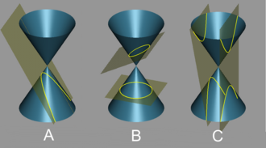

Irisan kerucut

Karena itu, kita membuat definisi umum berikut.

### Definisi: lokus nol suatu keluarga polinom

Misalkan $K$ suatu lapangan dan

$$F_j\in K[X_1,\ldots,X_n],\qquad j\in J,$$

suatu keluarga polinom dalam $n$ variabel. Himpunan

$$\{P\in\mathbb A_K^n\mid F_j(P)=0\text{ untuk setiap }j\in J\}$$

disebut *lokus nol* (atau *himpunan nol*) yang didefinisikan oleh keluarga tersebut. Himpunan ini ditulis $V(F_j,j\in J)$.

Subhimpunan ruang afin yang dapat muncul sebagai himpunan nol layak diberi nama tersendiri.

### Definisi: himpunan aljabar afin

Misalkan $K$ suatu lapangan dan $K[X_1,\ldots,X_n]$ gelanggang polinomial dalam $n$ variabel. Suatu subhimpunan $V\subseteq\mathbb A_K^n$ disebut *aljabar afin* apabila merupakan himpunan nol suatu keluarga polinom $F_j$, $j\in J$, dengan $F_j\in K[X_1,\ldots,X_n]$; yaitu, apabila

$$V=V(F_j,j\in J).$$

Contoh-contoh paling sederhana ialah himpunan titik berhingga pada garis afin $\mathbb A_K^1$, yang diberikan oleh sebuah polinom tunggal, serta subruang linear afin dalam $\mathbb A_K^n$, yang merupakan himpunan solusi suatu sistem persamaan linear takhomogen di atas $K$.

### Contoh: sumbu dan titik asal

Kita meninjau bidang afin $\mathbb A_K^2$ dan beberapa subhimpunan aljabar afin di dalamnya yang didefinisikan oleh variabel $X$ dan $Y$.

- Lokus nol $V(X,Y)$ hanya terdiri atas *titik asal* $(0,0)$, sebab kedua variabel harus bernilai nol.
- Himpunan $V(X)$ adalah *sumbu $Y$*, yakni semua titik berbentuk $(0,y)$.
- Himpunan $V(Y)$ adalah *sumbu $X$*.
- Himpunan $V(X+Y)$ terdiri atas semua titik $(x,y)$ dengan $y=-x$; ini adalah *antidiagonal*.
- Himpunan $V(XY)$ terdiri atas titik-titik $(x,y)$ dengan $xy=0$. Karena $K$ suatu lapangan, sebuah hasil kali hanya dapat bernilai nol jika salah satu faktornya nol. Jadi,

  $$V(XY)=V(X)\cup V(Y),$$

  yakni gabungan kedua sumbu koordinat.

Titik-titik dalam ruang afin atau pada suatu himpunan aljabar afin sering ditafsirkan sebagai representasi objek matematika lain yang lebih rumit. Sifat-sifat objek itu tercermin pada apakah titik yang merepresentasikannya memenuhi persamaan aljabar tertentu; dengan kata lain, pada apakah titik tersebut terletak pada himpunan aljabar afin tertentu. Contoh berikut menggambarkan gagasan ini.

### Contoh: matriks sebagai titik ruang afin

Sebuah matriks $2\times2$

$$\begin{pmatrix}
a_{11}&a_{21}\\
a_{12}&a_{22}
\end{pmatrix}$$

ditentukan secara unik oleh empat bilangan $a_{11},a_{21},a_{12},a_{22}\in K$. Karena itu, matriks tersebut dapat diidentifikasi dengan sebuah titik dalam $\mathbb A_K^4$. Dalam penafsiran ini, wajar jika variabel-variabelnya kita tulis $X_{11},X_{21},X_{12},X_{22}$. Sekarang kita dapat menanyakan sifat matriks mana yang dapat dideskripsikan oleh persamaan aljabar.

Sebuah matriks merupakan matriks segitiga atas tepat ketika $a_{12}=0$. Jadi, himpunan matriks segitiga atas adalah lokus nol $X_{12}$.

Sebuah matriks dapat dibalik apabila

$$a_{11}a_{22}-a_{12}a_{21}\ne0.$$

Karena itu, himpunan matriks yang tidak dapat dibalik dideskripsikan oleh syarat determinan aljabar

$$X_{11}X_{22}-X_{12}X_{21}=0.$$

Sebuah matriks mendeskripsikan perkalian oleh suatu skalar apabila matriks itu diagonal dengan entri diagonal yang sama. Himpunan ini dideskripsikan oleh tiga persamaan

$$X_{12}=0,\qquad X_{21}=0,\qquad X_{11}-X_{22}=0.$$

Suatu unsur $\lambda\in K$ adalah nilai eigen suatu matriks tepat ketika $\lambda$ merupakan akar polinom karakteristik matriks itu, yakni ketika

$$\det\begin{pmatrix}
\lambda-a_{11}&-a_{21}\\
-a_{12}&\lambda-a_{22}
\end{pmatrix}
=\lambda^2-\lambda(a_{11}+a_{22})+a_{11}a_{22}-a_{12}a_{21}=0.$$

Dalam aljabar linear, biasanya matriks diberikan dan kita mencari akar $\lambda$ dari polinom satu variabel ini. Kita juga dapat membalik sudut pandang: tetapkan $\lambda$, lalu pelajari lokus nol

$$\lambda^2-\lambda(X_{11}+X_{22})
+X_{11}X_{22}-X_{12}X_{21}=0$$

dalam empat variabel. Persamaan ini mendeskripsikan semua matriks yang mempunyai $\lambda$ sebagai nilai eigen.

Demikian pula, suatu matriks mempunyai dua nilai eigen berbeda $\lambda\ne\delta$ tepat ketika

$$\lambda^2-\lambda(X_{11}+X_{22})
+X_{11}X_{22}-X_{12}X_{21}=0$$

dan

$$\delta^2-\delta(X_{11}+X_{22})
+X_{11}X_{22}-X_{12}X_{21}=0.$$

Selisih kedua persamaan itu ialah

$$\lambda^2-\delta^2-(\lambda-\delta)(X_{11}+X_{22})=0.$$

Karena $\lambda\ne\delta$, kita dapat menulisnya sebagai

$$X_{11}+X_{22}=\lambda+\delta.$$

Jumlah entri diagonal sebuah matriks disebut *jejak* matriks. Persamaan terakhir menyatakan bahwa jejak matriks yang mempunyai nilai eigen $\lambda\ne\delta$ harus sama dengan jumlah kedua nilai eigen itu.

Polinom karakteristik matriks juga dapat ditulis

$$\lambda^2-\lambda\operatorname{Jejak}(M)+\det(M),$$

dengan

$$\operatorname{Jejak}(M)=X_{11}+X_{22},\qquad
\det(M)=X_{11}X_{22}-X_{12}X_{21}.$$

Jadi, dua matriks mempunyai polinom karakteristik yang sama tepat ketika jejak dan determinannya sama. Dengan demikian, himpunan matriks dengan polinom karakteristik tertentu dapat dipandang sebagai serat pemetaan

$$\mathbb A_K^4\longrightarrow\mathbb A_K^2,
\qquad M\longmapsto(\operatorname{Jejak}(M),\det(M)).$$

Pemetaan ini diberikan oleh ungkapan polinomial sederhana. Apakah pemetaan ini surjektif? Apakah semua seratnya mempunyai bentuk yang sama—apakah himpunan matriks dengan jejak dan determinan tertentu selalu mempunyai struktur yang sama—atau terdapat perbedaan?

Tetapkan $s$ dan $d$. Kita harus mempelajari himpunan solusi sistem

$$X_{11}+X_{22}=s,
\qquad
X_{11}X_{22}-X_{12}X_{21}=d.$$

Variabel $X_{11}$ ditentukan secara unik oleh $X_{22}$, dan sebaliknya. Karena itu, kita dapat *mengeliminasi* satu variabel dengan menetapkan $X_{22}=s-X_{11}$. Kita memperoleh sistem “ekuivalen” dalam tiga variabel $X_{11},X_{12},X_{21}$ dengan persamaan tunggal

$$X_{11}(s-X_{11})-X_{12}X_{21}=d,$$

atau

$$X_{11}^2-sX_{11}+X_{12}X_{21}+d=0.$$

Di sini “ekuivalen” berarti bahwa himpunan solusi kedua sistem saling berbijeksi melalui pemetaan yang diberikan oleh polinom. Bentuk terakhir menunjukkan bahwa solusi selalu ada: kita dapat menetapkan sebarang nilai bagi $X_{11}$ lalu memperoleh persamaan berbentuk $X_{12}X_{21}=a$, yang mempunyai solusi.

Dengan transformasi variabel linear, persamaan itu dapat disederhanakan lagi. Andaikan $2$ dapat dibalik dalam $K$—jadi karakteristik $K$ bukan $2$. Dengan

$$X=X_{11}-\frac{s}{2},\qquad Y=X_{12},\qquad Z=X_{21},$$

kita memperoleh

$$X^2+YZ+c=0,
\qquad
c=-\frac{s^2}{4}+d.$$

Karena itu, bentuk himpunan matriks dengan jejak dan determinan tertentu hanya bergantung pada $-s^2/4+d$. Bahkan, lokus nolnya berbeda menurut apakah suku ini nol atau tidak. Dalam kasus pertama lokus itu mempunyai singularitas; dalam kasus kedua tidak, sebagaimana akan kita lihat nanti.

## Ideal dan lokus nol

Karena untuk sementara kita mengizinkan keluarga polinom sebarang untuk mendefinisikan lokus nol dan himpunan aljabar afin, objek-objek itu pada awalnya tampak sulit dikendalikan. Namun, tiga pernyataan penting berlaku; kita akan membuktikannya secara bertahap.

1. Lokus nol suatu keluarga polinom sama dengan lokus nol ideal yang dibangkitkan oleh keluarga tersebut.
2. Setiap ideal mempunyai sistem pembangkit berhingga. Jadi, setiap lokus nol dapat dideskripsikan oleh berhingga banyak polinom (teorema basis Hilbert).
3. Di atas lapangan tertutup secara aljabar, lokus-lokus nol berkorespondensi secara bijektif dengan ideal-ideal radikal (teorema Nullstellensatz Hilbert).

Pernyataan pertama dapat segera kita buktikan. Dua pernyataan lainnya memerlukan persiapan aljabar yang akan kita kembangkan dalam kuliah-kuliah berikutnya.

### Lema: keluarga polinom dan ideal yang dibangkitkannya

Misalkan $K$ suatu lapangan dan $F_j\in K[X_1,\ldots,X_n]$, $j\in J$, suatu keluarga polinom dalam $n$ variabel. Misalkan $\mathfrak a$ adalah ideal dalam $K[X_1,\ldots,X_n]$ yang dibangkitkan oleh semua $F_j$. Maka

$$V(F_j,j\in J)=V(\mathfrak a).$$

#### Bukti

Ideal $\mathfrak a$ terdiri atas semua kombinasi linear berhingga dari polinom-polinom $F_j$ dan, khususnya, memuat setiap $F_j$. Karena itu, inklusi

$$V(F_j,j\in J)\supseteq V(\mathfrak a)$$

jelas. Untuk inklusi sebaliknya, ambil $P\in V(F_j,j\in J)$ dan $H\in\mathfrak a$. Terdapat polinom-polinom $A_i\in K[X_1,\ldots,X_n]$ dan indeks $j_1,\ldots,j_k$ sedemikian rupa sehingga

$$H=\sum_{i=1}^k A_iF_{j_i}.$$

Maka

$$H(P)=\sum_{i=1}^k A_i(P)F_{j_i}(P)=0.$$

Jadi, setiap unsur ideal tersebut lenyap di $P$, sehingga $P\in V(\mathfrak a)$. $\square$

Dengan demikian, selanjutnya kita dapat menganggap bahwa setiap himpunan nol diberikan oleh sebuah ideal.

### Lema: inklusi ideal membalik inklusi lokus nol

Untuk ideal-ideal $\mathfrak a\subseteq\mathfrak b$ dalam $K[X_1,\ldots,X_n]$, lokus-lokus nol yang bersesuaian memenuhi

$$V(\mathfrak a)\supseteq V(\mathfrak b).$$

#### Bukti

Ambil $P\in V(\mathfrak b)$. Artinya, $F(P)=0$ bagi setiap $F\in\mathfrak b$. Karena $\mathfrak a\subseteq\mathfrak b$, tentu $F(P)=0$ bagi setiap $F\in\mathfrak a$. Jadi, $P\in V(\mathfrak a)$. $\square$

Subhimpunan aljabar afin dari ruang afin memenuhi sifat-sifat struktural penting berikut.

### Proposisi: gabungan dan irisan himpunan aljabar afin

Misalkan $K$ suatu lapangan, $K[X_1,\ldots,X_n]$ gelanggang polinomial dalam $n$ variabel, dan $\mathbb A_K^n$ ruang afin yang bersesuaian. Sifat-sifat berikut berlaku.

1. $V(0)=\mathbb A_K^n$; jadi, seluruh ruang afin adalah himpunan aljabar afin.
2. $V(1)=\varnothing$; jadi, himpunan kosong adalah himpunan aljabar afin.
3. Jika $V_1,\ldots,V_k$ adalah himpunan aljabar afin dengan $V_i=V(\mathfrak a_i)$, maka

   $$V_1\cup V_2\cup\cdots\cup V_k
   =V(\mathfrak a_1\mathfrak a_2\cdots\mathfrak a_k).$$

   Khususnya, gabungan berhingga himpunan-himpunan aljabar afin juga merupakan himpunan aljabar afin.
4. Jika $V_i$, $i\in I$, adalah himpunan aljabar afin dengan $V_i=V(\mathfrak a_i)$, maka

   $$\bigcap_{i\in I}V_i=V\left(\sum_{i\in I}\mathfrak a_i\right).$$

   Khususnya, irisan sebarang banyak himpunan aljabar afin juga merupakan himpunan aljabar afin.

#### Bukti

Pernyataan (1) dan (2) jelas: polinom konstan $0$ lenyap di setiap titik, sedangkan polinom konstan $1$ tidak lenyap di titik mana pun.

Untuk (3), ambil titik dalam gabungan tersebut, katakanlah $P\in V(\mathfrak a_1)$. Maka $f(P)=0$ bagi setiap $f\in\mathfrak a_1$. Setiap unsur ideal hasil kali $\mathfrak a_1\cdots\mathfrak a_k$ berbentuk

$$h=\sum_{j=1}^m r_j f_{1j}f_{2j}\cdots f_{kj},$$

dengan $f_{ij}\in\mathfrak a_i$. Karena selalu $f_{1j}(P)=0$, kita memperoleh $h(P)=0$. Jadi, $P$ berada pada lokus nol di ruas kanan.

Sebaliknya, andaikan $P$ tidak berada dalam gabungan di ruas kiri. Maka $P\notin V(\mathfrak a_i)$ untuk setiap $i=1,\ldots,k$. Untuk setiap $i$, terdapat $f_i\in\mathfrak a_i$ dengan $f_i(P)\ne0$. Karena $K$ lapangan,

$$(f_1f_2\cdots f_k)(P)\ne0,$$

padahal $f_1f_2\cdots f_k\in\mathfrak a_1\cdots\mathfrak a_k$. Jadi, $P$ tidak mungkin berada pada lokus nol di ruas kanan.

Untuk (4), ambil $P\in\mathbb A_K^n$. Titik $P$ berada dalam $V(\mathfrak a_i)$ untuk setiap $i\in I$ tepat ketika $f(P)=0$ bagi setiap $f\in\mathfrak a_i$ dan setiap $i\in I$. Hal ini terjadi tepat ketika $f(P)=0$ bagi setiap $f$ dalam jumlah ideal-ideal tersebut. $\square$

[figure not shown]

Contoh himpunan aljabar

**Navigasi sumber:** mata kuliah · Kuliah 1 · Kuliah 3 (sumber) · Lembar Kerja 2

# Lembar Kerja 2

## Soal latihan

### Soal 2.1

Tinjau dua bidang dalam $\mathbb A_K^3$,

$$E_1=V(3x+4y+5z)
\qquad\text{dan}\qquad
E_2=V(2x-y+3z).$$

Berikan suatu parametrisasi bagi irisan $E_1\cap E_2$.

### Soal 2.2 ★

Tentukan titik-titik potong lingkaran satuan dengan garis yang melalui kedua titik $(-1,1)$ dan $(4,-2)$.

### Soal 2.3

Tentukan koordinat kedua titik potong garis $G$ dan lingkaran $K$, dengan $G$ diberikan oleh persamaan

$$3y-4x+2=0,$$

sedangkan $K$ mempunyai pusat $(2,5)$ dan jari-jari $7$.

### Soal 2.4

Hitung titik-titik potong kedua kurva

$$C=V(x^2+2y^2+3xy+x-2)
\qquad\text{dan}\qquad
L=V(4x+3y-5).$$

### Soal 2.5

Buktikan: irisan dua lingkaran yang berbeda pada bidang afin sama dengan irisan salah satu lingkaran tersebut dengan sebuah garis.

### Soal 2.6 ★

Tentukan titik-titik potong lingkaran satuan $E$ dengan lingkaran $K$ yang berpusat di $(1,0)$ dan berjari-jari $2$.

### Soal 2.7 ★

Tentukan titik-titik potong kedua elips

$$\{(x,y)\in\mathbb R^2\mid x^2+xy+3y^2=3\}$$

dan

$$\{(x,y)\in\mathbb R^2\mid 2x^2-xy+y^2=4\}.$$

### Soal 2.8 ★

Tentukan titik-titik potong lingkaran satuan dan parabola standar.

### Soal 2.9 ★

Misalkan

$$P=\{(x,y)\in\mathbb R^2\mid y=x^2\}$$

adalah parabola standar, dan $K$ lingkaran yang berpusat di $(0,1)$ dengan jari-jari $1$.

1. Buat sketsa $P$ dan $K$.
2. Tuliskan sebuah persamaan bagi $K$.
3. Tentukan irisan $P\cap K$.
4. Deskripsikan setengah busur bawah lingkaran sebagai grafik suatu fungsi dari $[-1,1]$ ke $\mathbb R$.
5. Deskripsikan posisi parabola relatif terhadap busur bawah lingkaran.

### Soal 2.10

Tentukan semua solusi simultan kedua persamaan

$$x^3+y^2=2
\qquad\text{dan}\qquad
2xy=3$$

untuk lapangan $K=\mathbb Z/(3)$, $\mathbb Z/(5)$, dan $\mathbb Z/(7)$.

### Soal 2.11 ★

Kita meninjau varietas matriks-matriks $2\times2$ yang saling komutatif, yakni himpunan pasangan matriks

$$V=\{(A,B)\mid A,B\in\operatorname{Mat}_2(K),\ AB=BA\}
\subseteq\operatorname{Mat}_2(K)\times\operatorname{Mat}_2(K)
\cong\mathbb A_K^8.$$

1. Buktikan bahwa $V$ adalah suatu varietas afin, dan tentukan persamaan yang sesederhana mungkin untuk mendeskripsikan varietas tersebut.
2. Buktikan bahwa pemetaan

   $$\pi:V\longrightarrow\operatorname{Mat}_2(K),
   \qquad(A,B)\longmapsto A,$$

   bersifat surjektif.
3. Tentukan praimaj

   $$\begin{pmatrix}1&1\\0&0\end{pmatrix}$$

   di bawah $\pi$.

### Soal 2.12

Buktikan bahwa untuk suatu titik

$$P=(a_1,\ldots,a_n)\in\mathbb A_K^n,$$

ideal yang bersesuaian

$$(X_1-a_1,X_2-a_2,\ldots,X_n-a_n)$$

adalah ideal maksimal.

### Soal 2.13

Misalkan $K$ suatu lapangan tertutup secara aljabar dan $n\ge2$. Buktikan bahwa sebuah titik $P\in\mathbb A_K^n$ tidak dapat menjadi himpunan nol dari satu polinom saja.

### Soal 2.14

Misalkan $K$ suatu lapangan berhingga dan

$$M=\{P_1,P_2,\ldots,P_m\}\subseteq\mathbb A_K^n$$

suatu himpunan titik berhingga. Buktikan bahwa $M$ adalah himpunan nol sebuah polinom tunggal.

### Soal 2.15 ★

Misalkan $K$ suatu lapangan. Buktikan bahwa ketiga ideal berikut dalam $K[X,Y,Z,W]$ adalah sama:

$$\mathfrak a=(Z^2+W^2-1,\ X-2Z^2+1,\ Y-2ZW),$$

$$\mathfrak b=(Z^2+W^2-1,\ X^2+Y^2-1,\ (1-X)Z-YW,\ YZ-(1+X)W),$$

dan

$$\mathfrak c=(Z^2+W^2-1,\ (1-X)Z-YW,\ YZ-(1+X)W).$$

### Soal 2.16 ★

Kita meninjau polinom

$$F=X^4Y^2+X^2Y^4-3X^2Y^2+1.$$

1. Temukan sebuah akar real dari $F$.
2. Verifikasi identitas

   $$\begin{aligned}
   F\cdot(X^2+Y^2+1)
   ={}&(X^2Y-Y)^2+(XY^2-X)^2+(X^2Y^2-1)^2\\
   &+\frac14(XY^3-X^3Y)^2
   +\frac34(XY^3+X^3Y-2XY)^2.
   \end{aligned}$$
3. Misalkan $K=\mathbb R$. Simpulkan bahwa

   $$F(x,y)\ge0$$

   untuk setiap titik $(x,y)\in\mathbb A_{\mathbb R}^2$.

**Catatan sumber.** Menurut suatu teorema Artin—penyelesaian masalah ke-17 Hilbert—setiap polinom real yang tidak pernah bernilai negatif dapat ditulis sebagai jumlah kuadrat fungsi-fungsi rasional. Polinom Motzkin $F$ di atas memberikan contoh konkret bahwa polinom seperti itu pada umumnya tidak dapat ditulis sebagai jumlah kuadrat polinom. Namun, di sini kita hanya membuktikan ketaknegatifannya.

### Soal 2.17

Tentukan pembangkit-pembangkit ideal bagi suatu ideal $\mathfrak a\subseteq\mathbb R[X,Y,Z]$ yang himpunan nolnya tepat terdiri atas empat titik

$$(2,3,4),\quad(1,1/5,0),\quad(0,0,1),\quad(-1,-2,\sqrt3)
\in\mathbb A_{\mathbb R}^3.$$

### Soal 2.18

Misalkan $\mathfrak a,\mathfrak b\subseteq R$ ideal-ideal dalam suatu gelanggang komutatif $R$. Buktikan hubungan

$$\mathfrak a\mathfrak b\subseteq\mathfrak a\cap\mathfrak b.$$

### Soal 2.19

Buktikan bahwa hasil kali ideal-ideal utama juga merupakan ideal utama.

### Soal 2.20 ★

Misalkan $I$ dan $J$ ideal-ideal dalam suatu gelanggang komutatif $R$, dan $n\in\mathbb N$. Buktikan persamaan

$$(I+J)^n=I^n+I^{n-1}J+I^{n-2}J^2+\cdots+I^2J^{n-2}+IJ^{n-1}+J^n.$$

### Soal 2.21

Misalkan $R$ suatu gelanggang komutatif dengan ideal-ideal $\mathfrak a,\mathfrak b\subseteq R$. Misalkan

$$S=R/\mathfrak b$$

dan $\widetilde{\mathfrak a}=\mathfrak aS$ ideal citranya. Buktikan bahwa

$$\mathfrak a^nS=\widetilde{\mathfrak a}^{\,n}.$$

### Soal 2.22

Misalkan $K$ suatu lapangan. Dalam $K[X,Y]$, tinjau kedua ideal prima

$$\mathfrak p=(X)\subset(X,Y)=\mathfrak m.$$

Buktikan bahwa tidak ada ideal $\mathfrak a$ dengan

$$\mathfrak p=\mathfrak a\mathfrak m.$$

## Soal untuk dikumpulkan

### Soal 2.23 — 3 poin

Tentukan semua solusi persamaan

$$x^2+y^2+xy=1$$

untuk lapangan $K=\mathbb F_2$, $\mathbb F_4$, dan $\mathbb F_8$. Anda dapat menggunakan [representasi lapangan-lapangan tersebut](https://de.wikiversity.org/wiki/Endliche_K%C3%B6rper/Nicht_Primk%C3%B6rper/Einige_Operationstafeln).

### Soal 2.24 — 3 poin

Misalkan

$$M=\{P_1,P_2,\ldots,P_m\}\subseteq\mathbb A_{\mathbb R}^n$$

suatu himpunan titik berhingga. Buktikan bahwa $M$ adalah himpunan nol sebuah polinom tunggal.

### Soal 2.25 — 3 poin

Buktikan bahwa himpunan matriks real $2\times2$ yang dapat ditriangularkan, dipandang sebagai subhimpunan $\mathbb A_{\mathbb R}^4$, bukan suatu himpunan aljabar afin.

### Soal 2.26 — 4 poin

Tentukan titik-titik potong kedua elips

$$\{(x,y)\in\mathbb R^2\mid4x^2-3xy+2y^2=7\}$$

dan

$$\{(x,y)\in\mathbb R^2\mid3x^2+4xy+5y^2=8\}.$$

### Soal 2.27 — 4 poin

Misalkan $S$ lokus nol dalam $\mathbb A_K^3$ yang diberikan oleh persamaan

$$x^2+y^2=z^2.$$

Irisan $S$ dengan sebuah bidang $E$ merupakan kurva dan dideskripsikan dalam $E$ oleh suatu persamaan dalam dua variabel yang sesuai. Temukan persamaan seperti itu untuk bidang-bidang

$$E_1=V(x),\qquad
E_2=V(z-1),\qquad
E_3=V(x+2y+3z),\qquad
E_4=V(3x-2z).$$

**Navigasi sumber:** Kuliah 2 · Lembar Kerja 3 (sumber) · Kuliah 1

# Solusi Lembar Kerja 2

Bagian ini menerjemahkan kesembilan solusi publik yang terhubung dari Lembar Kerja 2 pada pembekuan sumber. Nomor dan urutannya mengikuti soal sumber. Soal yang tidak mempunyai solusi publik pada batas tersebut tidak diberi solusi tambahan.

## Solusi Soal 2.2

Vektor arah garis tersebut ialah

$$\begin{pmatrix}5\\-3\end{pmatrix}.$$

Jadi, persamaan garisnya berbentuk

$$3x+5y=c.$$

Substitusi salah satu titik memberikan $c=2$. Dengan demikian,

$$y=\frac{2-3x}{5}.$$

Kita substitusikan ungkapan ini ke dalam persamaan lingkaran

$$x^2+y^2=1$$

dan memperoleh

$$x^2+\left(\frac{2-3x}{5}\right)^2=1,$$

atau

$$x^2+\frac{4-12x+9x^2}{25}-1
=\frac{34}{25}x^2-\frac{12}{25}x-\frac{21}{25}=0.$$

Setelah dinormalkan, persamaan itu menjadi

$$x^2-\frac6{17}x-\frac{21}{34}=0.$$

Karena itu,

$$\begin{aligned}
x_{1,2}
&=\frac{\frac6{17}\pm
\sqrt{\left(\frac6{17}\right)^2+4\cdot\frac{21}{34}}}{2}\\
&=\frac{\frac6{17}\pm
\sqrt{\left(\frac6{17}\right)^2+\frac{42}{17}}}{2}\\
&=\frac{6\pm\sqrt{6^2+714}}{34}\\
&=\frac{6\pm\sqrt{750}}{34}\\
&=\frac{6\pm5\sqrt{30}}{34},
\end{aligned}$$

dan

$$\begin{aligned}
y_{1,2}
&=\frac{2-3x_{1,2}}5\\
&=\frac{2-3\left(\frac{6\pm5\sqrt{30}}{34}\right)}5\\
&=\frac{68-3(6\pm5\sqrt{30})}{170}\\
&=\frac{50\mp15\sqrt{30}}{170}\\
&=\frac{10\mp3\sqrt{30}}{34}.
\end{aligned}$$

Jadi, titik-titik potongnya adalah

$$\left(\frac{6+5\sqrt{30}}{34},\frac{10-3\sqrt{30}}{34}\right)
\quad\text{dan}\quad
\left(\frac{6-5\sqrt{30}}{34},\frac{10+3\sqrt{30}}{34}\right).$$

Kembali ke Soal 2.2.

## Solusi Soal 2.6

Lingkaran satuan adalah himpunan solusi persamaan

$$x^2+y^2=1,$$

sedangkan $K$ adalah himpunan solusi persamaan

$$(x-1)^2+y^2=x^2-2x+1+y^2=4.$$

Dengan mengurangkan persamaan pertama dari persamaan kedua, kita memperoleh

$$-2x+1=3,$$

sehingga $x=-1$. Persamaan lingkaran satuan lalu memberikan $y=0$. Jadi, satu-satunya titik potong ialah $(-1,0)$, yang memang memenuhi kedua persamaan.

Kembali ke Soal 2.6.

## Solusi Soal 2.7

Kita mencari solusi sistem

$$x^2+xy+3y^2=3$$

dan

$$2x^2-xy+y^2=4.$$

Jumlah kedua persamaan tersebut adalah

$$3x^2+4y^2=7,$$

sedangkan dua kali persamaan pertama dikurangi persamaan kedua memberikan

$$3xy+5y^2=2.$$

Dari persamaan terakhir,

$$x=\frac{2-5y^2}{3y};$$

nilai $y=0$ jelas tidak menghasilkan solusi. Substitusi ungkapan bagi $x$ ke persamaan sebelumnya memberikan

$$3\left(\frac{2-5y^2}{3y}\right)^2+4y^2=7.$$

Setelah dikalikan dengan $3y^2$, kita memperoleh

$$\begin{aligned}
0
&=(2-5y^2)^2+12y^4-21y^2\\
&=4-20y^2+25y^4+12y^4-21y^2\\
&=37y^4-41y^2+4.
\end{aligned}$$

Ini adalah persamaan bikuadrat.

Kembali ke Soal 2.7.

## Solusi Soal 2.8

Parabola standar diberikan oleh persamaan

$$y=x^2,$$

sedangkan lingkaran satuan diberikan oleh

$$x^2+y^2=1.$$

Titik-titik potong harus memenuhi kedua persamaan secara simultan. Dengan mengganti $x^2$ pada persamaan kedua menggunakan persamaan pertama, kita memperoleh

$$y^2+y-1=0.$$

Jadi,

$$y=\frac{-1\pm\sqrt{1+4}}2=\frac{-1\pm\sqrt5}{2}.$$

Tanda negatif tidak memberikan nilai $x$ real, sehingga

$$y=\frac{-1+\sqrt5}{2},
\qquad
x=\pm\sqrt{\frac{-1+\sqrt5}{2}}.$$

Kedua titik potongnya adalah

$$\left(-\sqrt{\frac{-1+\sqrt5}{2}},\frac{-1+\sqrt5}{2}\right)$$

dan

$$\left(\sqrt{\frac{-1+\sqrt5}{2}},\frac{-1+\sqrt5}{2}\right).$$

Kembali ke Soal 2.8.

## Solusi Soal 2.9

1. Buat sketsa sesuai perintah soal.
2. Kita mempunyai

   $$\begin{aligned}
   K
   &=\{(x,y)\in\mathbb R^2\mid(y-1)^2+x^2=1\}\\
   &=\{(x,y)\in\mathbb R^2\mid y^2-2y+1+x^2=1\}\\
   &=\{(x,y)\in\mathbb R^2\mid y^2-2y+x^2=0\}.
   \end{aligned}$$
3. Kita mencari himpunan solusi bersama kedua persamaan

   $$y=x^2$$

   dan

   $$y^2-2y+x^2=0.$$

   Ganti $x^2$ dalam persamaan kedua dengan $y$. Kita memperoleh

   $$0=y^2-2y+y=y^2-y=y(y-1).$$

   Jadi, $y=0$ atau $y=1$. Ini memberikan tiga titik potong $(0,0)$, $(1,1)$, dan $(-1,1)$.
4. Persamaan lingkaran

   $$y^2-2y+x^2=0$$

   ekuivalen dengan

   $$y^2-2y=-x^2,$$

   dan dengan

   $$(y-1)^2=1-x^2.$$

   Karena itu,

   $$y=1\pm\sqrt{1-x^2}.$$

   Busur bawah lingkaran adalah grafik fungsi

   $$[-1,1]\longrightarrow\mathbb R,
   \qquad x\longmapsto1-\sqrt{1-x^2}.$$
5. Kita menyatakan bahwa pada $[-1,1]$ parabola berada di atas busur bawah lingkaran. Kita harus menunjukkan

   $$x^2\ge1-\sqrt{1-x^2}.$$

   Ini ekuivalen dengan

   $$\sqrt{1-x^2}\ge1-x^2.$$

   Karena kedua ruas taknegatif pada interval tersebut, hal ini ekuivalen dengan

   $$1-x^2\ge(1-x^2)^2=1+x^4-2x^2.$$

   Persamaan terakhir ekuivalen dengan $x^4-x^2\le0$, dan kemudian dengan $x^2-1\le0$, yang benar karena $x\in[-1,1]$.

Kembali ke Soal 2.9.

## Solusi Soal 2.11

1. Misalkan

   $$A=\begin{pmatrix}X_1&X_2\\X_3&X_4\end{pmatrix}
   \qquad\text{dan}\qquad
   B=\begin{pmatrix}Y_1&Y_2\\Y_3&Y_4\end{pmatrix}.$$

   Maka

   $$AB=
   \begin{pmatrix}
   X_1Y_1+X_2Y_3&X_1Y_2+X_2Y_4\\
   X_3Y_1+X_4Y_3&X_3Y_2+X_4Y_4
   \end{pmatrix}$$

   dan

   $$BA=
   \begin{pmatrix}
   X_1Y_1+X_3Y_2&X_2Y_1+X_4Y_2\\
   X_1Y_3+X_3Y_4&X_2Y_3+X_4Y_4
   \end{pmatrix}.$$

   Kedua matriks hasil kali ini sama tepat ketika keempat entri yang bersesuaian sama, yaitu ketika

   $$X_1Y_1+X_2Y_3=X_1Y_1+X_3Y_2,$$

   $$X_1Y_2+X_2Y_4=X_2Y_1+X_4Y_2,$$

   $$X_3Y_1+X_4Y_3=X_1Y_3+X_3Y_4,$$

   dan

   $$X_3Y_2+X_4Y_4=X_2Y_3+X_4Y_4.$$

   Karena itu, himpunannya adalah varietas afin. Persamaan pertama dan keempat saling ekuivalen dan keduanya ekuivalen dengan

   $$X_2Y_3=X_3Y_2.$$

   Jadi, matriks-matriks yang saling komutatif dideskripsikan oleh sistem

   $$X_2Y_3=X_3Y_2,$$

   $$X_1Y_2+X_2Y_4=X_2Y_1+X_4Y_2,$$

   $$X_3Y_1+X_4Y_3=X_1Y_3+X_3Y_4.$$
2. Matriks identitas $E_2$ komutatif dengan setiap matriks. Jadi, $(A,E_2)$ adalah salah satu praimaj dari $A$.
3. Kita mencari matriks

   $$B=\begin{pmatrix}Y_1&Y_2\\Y_3&Y_4\end{pmatrix}$$

   yang memenuhi sistem di atas untuk

   $$A=\begin{pmatrix}X_1&X_2\\X_3&X_4\end{pmatrix}
   =\begin{pmatrix}1&1\\0&0\end{pmatrix}.$$

   Syarat-syaratnya menjadi

   $$Y_3=0,
   \qquad
   Y_2+Y_4=Y_1,
   \qquad
   0=Y_3,$$

   dan syarat ketiga dapat dibuang. Jadi, praimaj matriks tersebut adalah

   $$\left\{
   \left(
   \begin{pmatrix}1&1\\0&0\end{pmatrix},
   \begin{pmatrix}Y_2+Y_4&Y_2\\0&Y_4\end{pmatrix}
   \right)
   \;\middle|\;Y_2,Y_4\in K
   \right\}.$$

Kembali ke Soal 2.11.

## Solusi Soal 2.15

Pertama-tama kita buktikan $\mathfrak b\subseteq\mathfrak a$ dengan menunjukkan bahwa setiap pembangkit $\mathfrak b$ bernilai $0$ dalam gelanggang faktor oleh $\mathfrak a$. Dalam gelanggang itu,

$$\begin{aligned}
X^2+Y^2
&=(2Z^2-1)^2+4Z^2W^2\\
&=(2Z^2-1)^2+4Z^2(1-Z^2)\\
&=4Z^4-4Z^2+1+4Z^2-4Z^4\\
&=1.
\end{aligned}$$

Selain itu,

$$\begin{aligned}
YW
&=2ZW^2\\
&=2Z(1-Z^2)\\
&=Z(2-2Z^2)\\
&=Z(1-2Z^2+1)\\
&=Z(1-X),
\end{aligned}$$

dan

$$\begin{aligned}
W(1+X)
&=W(2Z^2)\\
&=2WZ^2\\
&=ZY.
\end{aligned}$$

Inklusi $\mathfrak c\subseteq\mathfrak b$ jelas karena satu pembangkit dihilangkan.

Terakhir, kita buktikan $\mathfrak a\subseteq\mathfrak c$ dengan menunjukkan bahwa pembangkit-pembangkit $\mathfrak a$ bernilai $0$ dalam gelanggang hasil bagi oleh $\mathfrak c$. Dalam gelanggang itu berlaku

$$ZX=Z-YW
\qquad\text{dan}\qquad
WX=YZ-W.$$

Karena itu,

$$\begin{aligned}
X
&=X\cdot1\\
&=X(Z^2+W^2)\\
&=Z^2-ZYW+YZW-W^2\\
&=Z^2-W^2\\
&=2Z^2-1,
\end{aligned}$$

dan

$$\begin{aligned}
Y
&=Y\cdot1\\
&=Y(Z^2+W^2)\\
&=WXZ+WZ+ZW-ZXW\\
&=2ZW.
\end{aligned}$$

Kembali ke Soal 2.15.

## Solusi Soal 2.16

1. Jelas bahwa $(1,1)$ adalah suatu akar $F$.
2. Kita mempunyai

   $$\begin{aligned}
   F\cdot(X^2+Y^2+1)
   ={}&(X^4Y^2+X^2Y^4-3X^2Y^2+1)(X^2+Y^2+1)\\
   ={}&X^6Y^2+X^4Y^4-3X^4Y^2+X^2
   +X^4Y^4+X^2Y^6-3X^2Y^4+Y^2\\
   &+X^4Y^2+X^2Y^4-3X^2Y^2+1\\
   ={}&2X^4Y^4+X^6Y^2+X^2Y^6-2X^4Y^2-2X^2Y^4
   -3X^2Y^2+X^2+Y^2+1.
   \end{aligned}$$

   Untuk ruas lainnya,

   $$(X^2Y-Y)^2+(XY^2-X)^2+(X^2Y^2-1)^2
   +\frac14(XY^3-X^3Y)^2
   +\frac34(XY^3+X^3Y-2XY)^2,$$

   kita hitung koefisien setiap monom. Hanya derajat genap yang muncul dan derajat tertingginya $8$. Pada derajat itu hanya tiga suku terakhir yang berkontribusi, dan hanya monom $X^6Y^2$, $X^4Y^4$, dan $X^2Y^6$ yang muncul:

   $$X^6Y^2:\quad\frac14+\frac34=1,$$

   $$X^4Y^4:\quad1+\frac14(-2)+\frac34(2)=2,$$

   $$X^2Y^6:\quad\frac14+\frac34=1.$$

   Pada derajat $6$, hanya $X^4Y^2$ dan $X^2Y^4$ yang muncul:

   $$X^4Y^2:\quad1+\frac34(-4)=-2,$$

   $$X^2Y^4:\quad1+\frac34(-4)=-2.$$

   Pada derajat $4$, hanya $X^2Y^2$ yang muncul:

   $$X^2Y^2:\quad-2-2-2+\frac34(4)=-3.$$

   Pada derajat $2$, koefisien $X^2$ dan $Y^2$ masing-masing adalah $1$. Pada derajat $0$, koefisien $1$ juga $1$. Jadi, kedua ruas identik.
3. Dengan membagi identitas pada bagian (2) oleh $X^2+Y^2+1$ dalam lapangan hasil bagi $K[X,Y]$, kita memperoleh

   $$\begin{aligned}
   F=\frac{1}{X^2+Y^2+1}\Big(& (X^2Y-Y)^2+(XY^2-X)^2
   +(X^2Y^2-1)^2\\
   &+\frac14(XY^3-X^3Y)^2
   +\frac34(XY^3+X^3Y-2XY)^2\Big).
   \end{aligned}$$

   Karena $X^2+Y^2+1$ tidak mempunyai akar real, identitas ini juga berlaku sebagai identitas fungsional bagi fungsi-fungsi $\mathbb R^2\to\mathbb R$. Kuadrat tidak pernah negatif dan koefisien semua kuadrat yang terlibat positif. Jadi, fungsi tersebut taknegatif di setiap titik.

Kembali ke Soal 2.16.

## Solusi Soal 2.20

Untuk membuktikan inklusi $\subseteq$, ambil $f\in(I+J)^n$. Karena hasil kali ideal terdiri atas semua jumlah hasil kali, kita dapat menulis

$$f=f_1+f_2+\cdots+f_k,$$

dengan

$$f_\ell=c_{\ell1}c_{\ell2}\cdots c_{\ell n},$$

di mana $c_{\ell r}\in I+J$. Selanjutnya,

$$c_{\ell r}=a_{\ell r}+b_{\ell r}$$

dengan $a_{\ell r}\in I$ dan $b_{\ell r}\in J$. Jadi,

$$f_\ell=(a_{\ell1}+b_{\ell1})(a_{\ell2}+b_{\ell2})
\cdots(a_{\ell n}+b_{\ell n}).$$

Jika hasil kali ini dijabarkan secara distributif, kita memperoleh jumlah hasil-hasil kali yang masing-masing mempunyai $n$ faktor: $s$ faktor berasal dari $I$ dan $n-s$ faktor berasal dari $J$. Karena itu, setiap suku berada pada ruas kanan; demikian pula setiap $f_\ell$ dan akhirnya $f$.

Untuk membuktikan inklusi $\supseteq$, cukup ditunjukkan

$$I^sJ^{n-s}\subseteq(I+J)^n$$

bagi setiap $s$. Karena $I,J\subseteq I+J$, langsung diperoleh

$$I^sJ^{n-s}
\subseteq(I+J)^s(I+J)^{n-s}
=(I+J)^n.$$

Kembali ke Soal 2.20.

# Kuliah 3: Topologi Zariski, Ideal Pelenyapan, dan Radikal

## Topologi Zariski

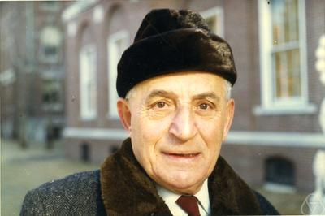

Oscar Zariski (1899-1986)

Dalam Proposisi 2.8 kita telah menunjukkan bahwa subhimpunan aljabar afin dari suatu ruang afin memenuhi aksioma-aksioma bagi himpunan tertutup suatu topologi. Topologi ini disebut *topologi Zariski*.

### Definisi: topologi Zariski

Pada ruang afin $\mathbb A_K^n$, *topologi Zariski* adalah topologi yang mendeklarasikan himpunan-himpunan aljabar afin sebagai himpunan tertutup.

Dengan demikian, himpunan terbuka dalam topologi Zariski adalah komplemen himpunan aljabar afin. Untuk suatu ideal $\mathfrak a$, komplemen ini ditulis

$$D(\mathfrak a)=\mathbb A_K^n\setminus V(\mathfrak a).$$

Topologi Zariski sangat berbeda dari topologi-topologi lain, terutama dari topologi yang diberikan oleh suatu metrik. Secara khusus, topologi Zariski bukan topologi Hausdorff. Secara umum, himpunan-himpunan terbuka yang takkosong dalam topologi Zariski sangat besar (lihat Soal 3.20), sedangkan himpunan-himpunan tertutup—yakni himpunan aljabar afin—sangat tipis, kecuali seluruh ruang itu sendiri.

### Contoh: topologi Zariski pada garis afin

Topologi Zariski pada garis afin $\mathbb A_K^1$ di atas suatu lapangan $K$ mudah dideskripsikan. Seluruh garis afin adalah himpunan tertutup yang diberikan oleh $V(0)$. Semua subhimpunan tertutup lainnya diberikan oleh $V(\mathfrak a)$ dengan $\mathfrak a\ne0$. Karena $K[X]$ adalah domain ideal utama, kita bahkan dapat menulis

$$\mathfrak a=(f),\qquad f\ne0.$$

Lokus nol yang bersesuaian hanya terdiri atas berhingga banyak titik. Sebaliknya, setiap titik tunggal $P$ berkoordinat $a$ adalah satu-satunya akar polinom linear $X-a$, sehingga

$$\{P\}=V(X-a)$$

tertutup dalam topologi Zariski. Kumpulan berhingga titik $P_1,\ldots,P_k$ dengan koordinat $a_1,\ldots,a_k$ adalah lokus nol polinom

$$(X-a_1)\cdots(X-a_k).$$

Jadi, himpunan-himpunan tertutup Zariski pada garis afin adalah semua subhimpunan berhingga—termasuk himpunan kosong—beserta seluruh garis afin.

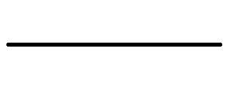

Sebuah garis di bidang

### Contoh: titik adalah tertutup

Setiap titik

$$P=(a_1,\ldots,a_n)\in\mathbb A_K^n$$

tertutup dalam topologi Zariski; tepatnya,

$$P=V(X_1-a_1,X_2-a_2,\ldots,X_n-a_n).$$

Selain himpunan kosong dan seluruh ruang, titik-titik adalah himpunan aljabar afin yang paling sederhana. Ideal

$$(X_1-a_1,X_2-a_2,\ldots,X_n-a_n),$$

yang disebut *ideal titik*, adalah ideal maksimal; lihat Soal 2.12.

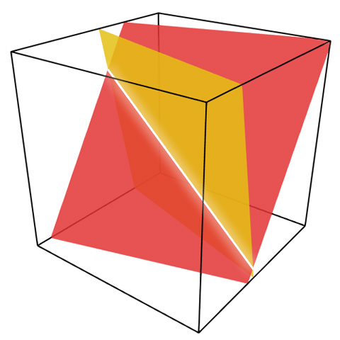

Irisan dua bidang

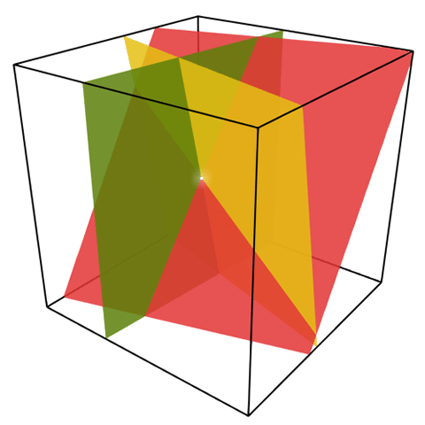

Irisan tiga bidang

Menurut Proposisi 2.8(3), setiap subhimpunan berhingga ruang afin tertutup dalam topologi Zariski. Karena itu, jika $E$ suatu himpunan titik berhingga, maka komplemennya

$$\mathbb A_K^n\setminus E$$

terbuka dalam topologi Zariski. Demikian pula, untuk fungsi rasional $P/Q$ dengan

$$P,Q\in K[X_1,\ldots,X_n],\qquad Q\ne0,$$

domain definisinya, yaitu $D(Q)$, terbuka.

## Ideal pelenyapan

### Definisi: ideal pelenyapan

Misalkan $T\subseteq\mathbb A_K^n$ suatu subhimpunan. Himpunan

$$\operatorname{Id}(T)
=\{F\in K[X_1,\ldots,X_n]\mid F(P)=0
\text{ untuk setiap }P\in T\}$$

disebut *ideal pelenyapan* dari $T$.

Himpunan ini memang sebuah ideal. Jika $F(P)=0$ dan $G(P)=0$ untuk setiap $P\in T$, maka hal yang sama berlaku bagi jumlah $F+G$ dan bagi setiap kelipatan $HF$.

Jadi, kita mempunyai dua pemetaan dengan arah berlawanan: suatu subhimpunan ruang afin dipetakan ke ideal pelenyapannya, sedangkan suatu ideal dalam gelanggang polinomial dipetakan ke lokus nolnya. Kita ingin memahami sejauh mana ideal dan lokus nol saling bersesuaian.

### Contoh: himpunan kosong dan seluruh ruang

Ideal pelenyapan himpunan kosong adalah ideal satuan, sebab tidak ada titik tempat syarat pelenyapan perlu diperiksa.

Ideal pelenyapan seluruh ruang $\mathbb A_K^n$ bergantung pada medannya. Jika $K$ takhingga, hanya polinom nol yang lenyap di mana-mana, sehingga ideal pelenyapannya adalah ideal nol. Pernyataan ini mengikuti dari Soal 3.18.

Sebaliknya, jika $K$ adalah lapangan berhingga dengan $q$ unsur, maka

$$x^q-x=0$$

untuk setiap $x\in K$. Karena itu, polinom $X^q-X$ lenyap di setiap titik garis afin dan termasuk dalam ideal pelenyapan garis afin tersebut. Pada dimensi yang lebih tinggi,

$$\operatorname{Id}(\mathbb A_K^n)
=(X_1^q-X_1,X_2^q-X_2,\ldots,X_n^q-X_n).$$

### Contoh: ideal pelenyapan sebuah titik

Misalkan

$$P=(a_1,\ldots,a_n)\in\mathbb A_K^n.$$

Maka

$$\operatorname{Id}(P)=(X_1-a_1,\ldots,X_n-a_n).$$

Mula-mula, polinom linear $X_i-a_i$ jelas lenyap di $P$, sebab $(X_i-a_i)(P)=a_i-a_i=0$. Dengan demikian, ideal yang dibangkitkan oleh polinom-polinom tersebut termuat dalam ideal pelenyapan.

Sebaliknya, misalkan $F$ suatu polinom dengan $F(P)=0$. Tulis $F$ dalam “variabel baru”

$$\widetilde X_1=X_1-a_1,\ldots,
\widetilde X_n=X_n-a_n$$

dengan mengganti $X_i$ oleh $X_i-a_i+a_i$. Dalam variabel baru itu, tulis

$$F=\sum_\nu b_\nu\widetilde X^\nu.$$

Polinom ini terdiri atas suku konstan $b_0$, sedangkan setiap monom lainnya memuat sekurang-kurangnya satu variabel. Jadi, untuk polinom-polinom tertentu $F_i$, kita dapat menulis

$$F=F_1\widetilde X_1+\cdots+F_n\widetilde X_n+c.$$

Karena $F(P)=c=0$, kita memperoleh

$$F\in(\widetilde X_1,\ldots,\widetilde X_n)
=(X_1-a_1,\ldots,X_n-a_n).$$

### Lema: inklusi subhimpunan membalik inklusi ideal pelenyapan

Misalkan $V\subseteq W\subseteq\mathbb A_K^n$. Maka

$$\operatorname{Id}(W)\subseteq\operatorname{Id}(V).$$

#### Bukti

Ambil $F\in\operatorname{Id}(W)$. Dengan kata lain, $F(P)=0$ untuk setiap $P\in W$. Karena $V\subseteq W$, khususnya $F(P)=0$ untuk setiap $P\in V$. Jadi, $F\in\operatorname{Id}(V)$. $\square$

### Lema: hubungan antara lokus nol dan ideal pelenyapan

Misalkan $I\subseteq K[X_1,\ldots,X_n]$ suatu ideal dan $T\subseteq\mathbb A_K^n$ suatu subhimpunan. Pernyataan-pernyataan berikut berlaku.

1. $T\subseteq V(\operatorname{Id}(T))$.
2. $I\subseteq\operatorname{Id}(V(I))$.
3. $V(I)=V(\operatorname{Id}(V(I)))$.
4. $\operatorname{Id}(T)=\operatorname{Id}(V(\operatorname{Id}(T)))$.

#### Bukti

Untuk (1), ambil $P\in T$. Menurut definisi, setiap polinom $F\in\operatorname{Id}(T)$ lenyap pada $T$, sehingga $P\in V(\operatorname{Id}(T))$.

Untuk (2), ambil $F\in I$. Polinom $F$ lenyap pada seluruh $V(I)$, sehingga $F\in\operatorname{Id}(V(I))$.

Untuk (3), terapkan (1) pada $T=V(I)$ untuk memperoleh inklusi $V(I)\subseteq V(\operatorname{Id}(V(I)))$. Menurut (2), $I\subseteq\operatorname{Id}(V(I))$; penerapan $V(-)$ dan Lema 2.7 memberikan inklusi sebaliknya.

Pernyataan (4) dibuktikan dengan cara yang sama. $\square$

### Contoh: inklusi yang tegas

Kedua inklusi pada Lema 3.8(1) dan (2) dapat bersifat tegas. Sebagai contoh, misalkan $T\subsetneq\mathbb A_K^1$ suatu subhimpunan takhingga yang proper; ini mensyaratkan bahwa $K$ takhingga. Maka

$$\operatorname{Id}(T)=0,$$

sehingga $V(0)=\mathbb A_K^1$ benar-benar lebih besar daripada $T$.

Untuk inklusi pada (2), ambil $R=K[X]$ dan $I=(X^2)$. Maka

$$V(I)=\{0\},\qquad \operatorname{Id}(\{0\})=(X),$$

tetapi $X\notin(X^2)$. Contoh yang lebih ekstrem dalam $R=\mathbb R[X,Y]$ ialah $I=(X^2+Y^2)$, dengan $V(I)=\{(0,0)\}$. Ideal pelenyapan titik tersebut adalah $(X,Y)$.

### Lema: penutupan Zariski

Misalkan $T\subseteq\mathbb A_K^n$. Penutupan Zariski dari $T$ adalah

$$\overline T=V(\operatorname{Id}(T)).$$

#### Bukti

Inklusi $T\subseteq V(\operatorname{Id}(T))$ telah dibuktikan dalam Lema 3.8(1). Karena $V(\operatorname{Id}(T))$ tertutup menurut definisi, kita memperoleh

$$\overline T\subseteq V(\operatorname{Id}(T)).$$

Sebaliknya, ambil $P\in V(\operatorname{Id}(T))$ dan andaikan $P\notin\overline T$. Maka terdapat himpunan terbuka Zariski $U$ sedemikian rupa sehingga

$$P\in U,
\qquad
U\cap T=\varnothing.$$

Tuliskan $U=D(\mathfrak a)$. Syarat $P\in U$ berarti terdapat $G\in\mathfrak a$ dengan $G(P)\ne0$. Maka

$$P\in D(G)\subseteq U,$$

sehingga $T\cap D(G)=\varnothing$. Jadi, $T\subseteq V(G)$ dan $G\in\operatorname{Id}(T)$. Namun, $G(P)\ne0$ bertentangan dengan $P\in V(\operatorname{Id}(T))$. $\square$

## Radikal

### Definisi: ideal radikal

Suatu ideal $\mathfrak a$ dalam gelanggang komutatif $R$ disebut *ideal radikal* apabila berlaku: jika $f^n\in\mathfrak a$ untuk suatu $n\in\mathbb N$, maka sudah pasti $f\in\mathfrak a$.

### Definisi: radikal suatu ideal

Misalkan $R$ suatu gelanggang komutatif dan $\mathfrak a\subseteq R$ suatu ideal. Himpunan

$$\operatorname{rad}(\mathfrak a)
=\{f\in R\mid\text{terdapat }r\text{ dengan }f^r\in\mathfrak a\}$$

disebut *radikal* dari $\mathfrak a$.

Radikal suatu ideal sendiri merupakan ideal radikal.

### Lema: radikal suatu ideal adalah ideal radikal

Misalkan $R$ suatu gelanggang komutatif dan $\mathfrak a\subseteq R$ suatu ideal. Maka $\operatorname{rad}(\mathfrak a)$ adalah ideal radikal.

#### Bukti

Mula-mula kita buktikan bahwa himpunan tersebut merupakan ideal. Jelas bahwa $0$ berada dalam radikal. Jika $f\in\operatorname{rad}(\mathfrak a)$, katakan $f^r\in\mathfrak a$, maka

$$(af)^r=a^rf^r\in\mathfrak a,$$

sehingga $af$ berada dalam radikal. Untuk sifat penjumlahan, misalkan $f,g\in\operatorname{rad}(\mathfrak a)$ dengan $f^r\in\mathfrak a$ dan $g^s\in\mathfrak a$. Maka

$$\begin{aligned}
(f+g)^{r+s}
&=\sum_{i+j=r+s}\binom{r+s}{i}f^ig^j\\
&=\sum_{\substack{i+j=r+s\\i<r}}\binom{r+s}{i}f^ig^j
+\sum_{\substack{i+j=r+s\\i\ge r}}\binom{r+s}{i}f^ig^j
\in\mathfrak a.
\end{aligned}$$

Sekarang andaikan $f^k\in\operatorname{rad}(\mathfrak a)$. Maka untuk suatu $r$ berlaku

$$(f^k)^r=f^{kr}\in\mathfrak a,$$

sehingga $f\in\operatorname{rad}(\mathfrak a)$. $\square$

### Lema: ideal pelenyapan adalah ideal radikal

Misalkan $T\subseteq\mathbb A_K^n$. Maka ideal pelenyapan $\operatorname{Id}(T)$ adalah ideal radikal.

#### Bukti

Misalkan $F\in K[X_1,\ldots,X_n]$ dan $F^s\in\operatorname{Id}(T)$. Maka

$$F^s(P)=0$$

untuk setiap $P\in T$. Karena itu, $F(P)=0$ untuk setiap $P\in T$, sehingga $F\in\operatorname{Id}(T)$. $\square$

Kelak kita akan melihat bahwa di atas lapangan tertutup secara aljabar, ideal radikal dan lokus nol aljabar saling bersesuaian. Inilah isi teorema Nullstellensatz Hilbert.

**Navigasi sumber:** mata kuliah · Kuliah 2 · Kuliah 4 (sumber) · Lembar Kerja 3

# Lembar Kerja 3

## Soal latihan

### Soal 3.1

Buktikan bahwa subhimpunan terbuka Zariski yang takkosong pada garis afin $\mathbb A_K^1$ tepat merupakan domain definisi maksimal fungsi-fungsi rasional.

### Soal 3.2

Misalkan $K$ suatu lapangan takhingga dan $P\in K[X]$ suatu polinom takkonstan. Buktikan bahwa fungsi

$$P:K\longrightarrow K$$

yang didefinisikan oleh $P$ mengambil takhingga banyak nilai.

### Soal 3.3

1. Buat sketsa lokus nol real dari $Y^n-X^n$.
2. Tentukan ideal pelenyapan dari himpunan aljabar afin $V_n\subseteq\mathbb A_{\mathbb R}^2$ yang merupakan gabungan semua garis melalui titik asal dan melalui titik-titik sudut suatu segi-$n$ beraturan, dengan $(1,0)$ sebagai salah satu titik sudutnya.

### Soal 3.4

Deskripsikan suatu pemetaan

$$\varphi:\mathbb A_K^1\longrightarrow\mathbb A_K^1$$

yang kontinu terhadap topologi Zariski, tetapi tidak diberikan oleh suatu polinom.

### Soal 3.5

Misalkan

$$V\subseteq\mathbb A_{\mathbb C}^n=\mathbb C^n$$

suatu himpunan aljabar afin. Buktikan bahwa, di bawah identifikasi

$$\mathbb C^n=\mathbb R^{2n},$$

subhimpunan $V$ juga merupakan suatu himpunan aljabar afin dalam $\mathbb A_{\mathbb R}^{2n}$. Buktikan bahwa pernyataan sebaliknya tidak berlaku.

### Soal 3.6

Misalkan $(M,d)$ suatu ruang metrik dan $T\subseteq M$ suatu subhimpunan takkosong. Buktikan bahwa

$$d_T(x):=\inf\{d(x,y)\mid y\in T\}$$

mendefinisikan suatu fungsi kontinu yang terdefinisi dengan baik $M\to\mathbb R$.

### Soal 3.7

Misalkan $(M,d)$ suatu ruang metrik dan $T\subseteq M$ suatu subhimpunan. Buktikan bahwa $T$ tertutup tepat ketika terdapat suatu fungsi kontinu

$$f:M\longrightarrow\mathbb R$$

dengan

$$f^{-1}(0)=T.$$

### Soal 3.8

Buktikan bahwa, untuk $r>0$, bola terbuka $U(P,r)$ dalam $\mathbb R^n$ tidak terbuka dalam topologi Zariski dan bola tertutup $B(P,r)$ tidak tertutup dalam topologi Zariski.

### Soal 3.9

Karakterisasikan ideal-ideal radikal dalam $\mathbb Z$ dengan menggunakan faktorisasi prima.

### Definisi pengantar: unsur nilpoten

Suatu unsur $a$ dalam gelanggang komutatif $R$ disebut *nilpoten* apabila

$$a^n=0$$

untuk suatu bilangan asli $n$.

### Soal 3.10

Misalkan $R$ suatu gelanggang komutatif dan $f,g\in R$ unsur-unsur nilpoten. Buktikan bahwa jumlah $f+g$ juga nilpoten.

### Soal 3.11 ★

Misalkan $R$ suatu gelanggang komutatif dan $f\in R$ suatu unsur nilpoten. Buktikan bahwa $1+f$ adalah suatu unit.

### Soal 3.12

Misalkan $R$ suatu gelanggang komutatif dan $r\in R$ suatu unsur nilpoten. Konstruksikan sebuah polinom linear dalam $R[X]$ yang merupakan suatu unit, dan berikan pula inversnya.

### Definisi pengantar: gelanggang tereduksi

Suatu gelanggang komutatif $R$ disebut *tereduksi* apabila $0$ adalah satu-satunya unsur nilpoten dalam $R$.

### Soal 3.13 ★

Buktikan bahwa suatu ideal $\mathfrak a$ dalam gelanggang komutatif $R$ adalah ideal radikal tepat ketika gelanggang faktor $R/\mathfrak a$ tereduksi.

### Soal 3.14

Misalkan $\mathfrak a\subseteq R$ suatu ideal dalam gelanggang komutatif $R$. Buktikan bahwa semua pangkat

$$\mathfrak a^n,\qquad n\in\mathbb N_+,$$

mempunyai radikal yang sama.

### Soal 3.15

Buktikan bahwa setiap ideal prima adalah ideal radikal.

### Soal 3.16

Misalkan $R$ dan $S$ gelanggang-gelanggang komutatif, $\varphi:R\to S$ suatu homomorfisme gelanggang, dan $\mathfrak a$ suatu ideal radikal dalam $S$. Buktikan bahwa praimaj $\varphi^{-1}(\mathfrak a)$ adalah ideal radikal dalam $R$.

### Soal 3.17

Misalkan $\mathfrak a$ dan $\mathfrak b$ ideal-ideal dalam $K[X_1,\ldots,X_n]$ dengan radikal yang sama. Buktikan bahwa lokus nol keduanya juga sama. Dengan sebuah contoh, buktikan bahwa pernyataan sebaliknya tidak berlaku.

### Soal 3.18

Misalkan $K$ suatu lapangan takhingga, $F\in K[X_1,\ldots,X_n]$ suatu polinom, dan $U\subseteq\mathbb A_K^n$ suatu subhimpunan terbuka Zariski yang takkosong. Andaikan $F|_U=0$ sebagai fungsi. Buktikan bahwa $F$ adalah polinom nol.

## Soal untuk dikumpulkan

### Soal 3.19 — 3 poin

Misalkan

$$\varphi:\mathbb A_K^n\longrightarrow\mathbb A_K^m$$

suatu pemetaan yang diberikan oleh $m$ polinom dalam $n$ variabel. Buktikan bahwa $\varphi$ kontinu terhadap topologi Zariski.

### Soal 3.20 — 4 poin

Misalkan $K$ suatu lapangan takhingga. Buktikan bahwa setiap subhimpunan terbuka Zariski yang takkosong

$$U\subseteq\mathbb A_K^n$$

bersifat padat.

**Petunjuk sumber:** Reduksikan ke kasus $n=1$. Jangan gunakan Soal 3.18.

### Soal 3.21 — 5 poin

Tentukan penutupan Zariski bagi setiap subhimpunan bidang afin $\mathbb A_K^2$ berikut.

1. $\{(x,\sin x)\mid x\in\mathbb R\}$.
2. $\{(\cos x,\sin x)\mid x\in\mathbb R\}$.
3. $\{(x,x^3)\mid 0\le x\le1,\ x\in\mathbb R\}$.
4. $\{(x,x^3)\mid 0\le x\le1,\ x\in\mathbb Q\}$.
5. $\{(x,x^3)\mid x\in\mathbb Z/(5)\}$.

Soal berikut menggunakan beberapa istilah topologi yang lebih lanjut.

### Soal 3.22 — 4 poin

Misalkan $K$ suatu lapangan.

1. Buktikan bahwa untuk $K=\mathbb R$ maupun $K=\mathbb C$, topologi standar (topologi metrik atau Euklides) lebih halus daripada topologi Zariski pada $\mathbb A_K^1$.
2. Buktikan bahwa topologi Zariski pada $\mathbb A_K^1$ sama dengan topologi kofinit. Apakah hal ini juga berlaku pada $\mathbb A_K^n$ untuk $n\ge2$?
3. Kapan topologi Zariski pada $\mathbb A_K^n$ memenuhi sifat $T_1$? Kapan topologi tersebut Hausdorff?
4. Seperti apakah topologi Zariski pada $\mathbb A_K^n$ jika $K$ suatu lapangan berhingga?

**Navigasi sumber:** Kuliah 3 · solusi publik Unit 3 · Lembar Kerja 2 · Lembar Kerja 4 (sumber)

# Solusi Publik Lembar Kerja 3

Sumber hanya menyediakan solusi publik bagi Soal 3.11 dan 3.13 pada batas revisi yang dibekukan. Tidak ada solusi tambahan yang dibuat untuk edisi ini.

## Solusi Soal 3.11

Misalkan $f^k=0$. Maka

$$\begin{aligned}
&(1+f)(1-f+f^2-f^3+f^4\pm\cdots\pm f^{k-1})\\
&=1-f+f^2-f^3+f^4\pm\cdots\pm f^{k-1}
+f-f^2+f^3-f^4\mp\cdots\mp f^{k-1}\\
&=1.
\end{aligned}$$

Jadi, unsur

$$1-f+f^2-f^3+f^4\pm\cdots\pm f^{k-1}$$

adalah invers dari $1+f$, sehingga $1+f$ merupakan suatu unit.

Kembali ke Soal 3.11.

## Solusi Soal 3.13

Misalkan $\mathfrak a$ suatu ideal radikal dan $f\in R/\mathfrak a$ nilpoten. Maka

$$f^r=0$$

dalam $R/\mathfrak a$ untuk suatu $r$. Jika diterjemahkan kembali ke $R$, pernyataan ini berarti $f^r\in\mathfrak a$. Karena $\mathfrak a$ adalah ideal radikal, kita memperoleh $f\in\mathfrak a$, sehingga $f=0$ dalam gelanggang faktor. Jadi, gelanggang faktor tersebut tereduksi.

Sebaliknya, misalkan diberikan ideal

$$\mathfrak a\subseteq R$$

dengan gelanggang faktor $R/\mathfrak a$ yang tereduksi. Andaikan $f^r\in\mathfrak a$. Maka kelas sisa $f^r$ sama dengan $0$. Karena gelanggang faktor tersebut tereduksi, kelas sisa $f$ sendiri sudah sama dengan $0$. Artinya, $f\in\mathfrak a$, sehingga ideal itu adalah ideal radikal.

Kembali ke Soal 3.13.

# Kuliah 4: Ketaktereduksian, Komponen, dan Irisan Kurva

## Himpunan aljabar afin yang tak tereduksi

### Definisi: himpunan tak tereduksi

Suatu himpunan aljabar afin

$$V\subseteq\mathbb A_K^n$$

disebut *tak tereduksi* apabila $V\ne\varnothing$ dan tidak ada dekomposisi

$$V=Y\cup Z$$

dengan himpunan-himpunan aljabar afin $Y,Z\subsetneq V$.

Jadi, himpunan tertutup Zariski $V$ tak tereduksi tepat ketika $V\ne\varnothing$ dan setiap dekomposisi $V=Y\cup Z$ memaksa $V=Y$ atau $V=Z$. Pernyataan yang sama segera berlaku bagi setiap penyajian berhingga sebagai gabungan himpunan tertutup.

Ketaktereduksian adalah sifat yang sepenuhnya topologis. Dalam ruang topologis umum, definisi di atas dirumuskan dengan himpunan tertutup sebagai pengganti himpunan aljabar afin, yang memang merupakan himpunan tertutup dalam topologi Zariski.

Gambar-gambar berikut menunjukkan beberapa subhimpunan aljabar afin yang tak tereduksi maupun yang tereduksi. Apa komponen-komponen tak tereduksinya (lihat definisi di bawah)?

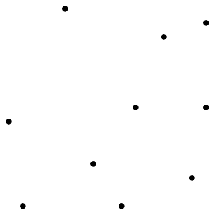

Titik-titik untuk triangulasi Delaunay

[figure not shown]

Sebuah garis

[figure not shown]

Beberapa garis lurus

### Contoh: ruang afin

Pertimbangkan ruang afin $\mathbb A_K^n$. Jika $K$ berhingga, ruang ini hanya terdiri atas berhingga banyak titik dan hanya subhimpunan satu titik yang tak tereduksi. Khususnya, kecuali untuk $n=0$, ruang afin tersebut tidak tak tereduksi.

Sebaliknya, jika $K$ takhingga, ruang afin $\mathbb A_K^n$ tak tereduksi. Andaikan

$$\mathbb A_K^n=Y\cup Z$$

dengan $Y$ dan $Z$ subhimpunan aljabar afin yang keduanya proper. Untuk komplemen terbukanya,

$$U=\mathbb A_K^n\setminus Y,
\qquad
W=\mathbb A_K^n\setminus Z,$$

berlaku $U,W\ne\varnothing$, tetapi $U\cap W=\varnothing$. Hal ini bertentangan dengan Soal 3.20.

### Lema: ketaktereduksian dan ideal prima

Misalkan $V\subseteq\mathbb A_K^n$ suatu himpunan aljabar afin dengan ideal pelenyapan $\operatorname{Id}(V)$. Maka $V$ tak tereduksi tepat ketika $\operatorname{Id}(V)$ merupakan ideal prima.

#### Bukti

Mula-mula andaikan $\operatorname{Id}(V)$ bukan ideal prima. Jika

$$\operatorname{Id}(V)=K[X_1,\ldots,X_n],$$

maka $V=\varnothing$, sehingga $V$ tidak tak tereduksi menurut definisi. Selain kasus itu, terdapat polinom

$$F,G\in K[X_1,\ldots,X_n]$$

dengan

$$FG\in\operatorname{Id}(V),
\qquad
F,G\notin\operatorname{Id}(V).$$

Karena itu terdapat $P,Q\in V$ dengan $F(P)\ne0$ dan $G(Q)\ne0$. Bentuk dua ideal

$$\mathfrak a_1=\operatorname{Id}(V)+(F),
\qquad
\mathfrak a_2=\operatorname{Id}(V)+(G).$$

Menurut Lema 3.8(3),

$$V(\mathfrak a_1),V(\mathfrak a_2)
\subseteq V(\operatorname{Id}(V))=V.$$

Kedua inklusi ini proper karena $P\notin V(\mathfrak a_1)$ dan $Q\notin V(\mathfrak a_2)$. Di sisi lain,

$$V(\mathfrak a_1)\cup V(\mathfrak a_2)
=V(\mathfrak a_1\mathfrak a_2)
=V(\operatorname{Id}(V))
=V.$$

Jadi, $V$ mempunyai dekomposisi taktrivial dan tidak tak tereduksi.

Sekarang andaikan $V$ tidak tak tereduksi. Jika $V=\varnothing$, maka $\operatorname{Id}(V)$ adalah seluruh gelanggang dan bukan ideal prima. Andaikan selanjutnya $V\ne\varnothing$ dan

$$V=Y\cup Z$$

merupakan dekomposisi taktrivial. Tuliskan

$$Y=V(\mathfrak a_1),
\qquad
Z=V(\mathfrak a_2).$$

Karena $Y\subsetneq V$, ada titik

$$P\in V=V(\operatorname{Id}(V)),
\qquad
P\notin V(\mathfrak a_1).$$

Maka ada $F\in\mathfrak a_1$ dengan $F(P)\ne0$, sehingga $F\notin\operatorname{Id}(V)$. Dengan cara yang sama, ada $G\in\mathfrak a_2$ dengan $G\notin\operatorname{Id}(V)$. Untuk setiap $Q\in V=Y\cup Z$, berlaku $(FG)(Q)=0$, sebab $F$ lenyap pada $Y$ dan $G$ lenyap pada $Z$. Jadi,

$$FG\in\operatorname{Id}(V),$$

meskipun kedua faktornya tidak berada dalam ideal tersebut. Dengan demikian, $\operatorname{Id}(V)$ bukan ideal prima. $\square$

### Definisi: komponen tak tereduksi

Misalkan $V$ suatu himpunan aljabar afin. Suatu subhimpunan aljabar afin $W\subseteq V$ disebut *komponen tak tereduksi* dari $V$ apabila $W$ tak tereduksi dan tidak ada subhimpunan tak tereduksi $W'$ dengan

$$W\subsetneq W'\subseteq V.$$

Jika $V$ tak tereduksi, maka $V$ sendiri merupakan satu-satunya komponen tak tereduksi dari $V$. Dalam Teorema 9.11 kelak akan dibuktikan bahwa setiap himpunan aljabar afin dapat ditulis sebagai gabungan berhingga komponen tak tereduksi.

### Contoh: perilaku di atas bilangan real dan kompleks

Pertimbangkan persamaan

$$F=Y^2+X^2(X+1)^2=0.$$

Di atas bilangan real, persamaan ini mempunyai dua solusi. Karena kuadrat real tidak pernah negatif, $F$ hanya dapat bernilai nol jika kedua sukunya nol. Akibatnya, $Y=0$ dan $X=0$ atau $X=-1$. Khususnya, himpunan solusi realnya tidak terhubung dan tidak tak tereduksi; ideal pelenyapannya dalam situasi real ini juga sangat besar.

Di atas bilangan kompleks terdapat faktorisasi

$$F=(Y+iX(X+1))(Y-iX(X+1))$$

menjadi polinom-polinom tak tereduksi. Hal ini sekaligus menunjukkan bahwa $F$, sebagai polinom dalam $\mathbb R[X,Y]$, tak tereduksi, meskipun lokus nol realnya tidak tak tereduksi. Lokus nol kompleksnya terdiri atas kedua grafik

$$Y=\pm iX(X+1),$$

yang beririsan di $(0,0)$ dan $(-1,0)$.

Untuk persamaan

$$Y^2+Z^2+X^2(X+1)^2=0$$

kembali hanya ada dua titik solusi real, sedangkan polinomnya tak tereduksi baik di atas bilangan real maupun kompleks.

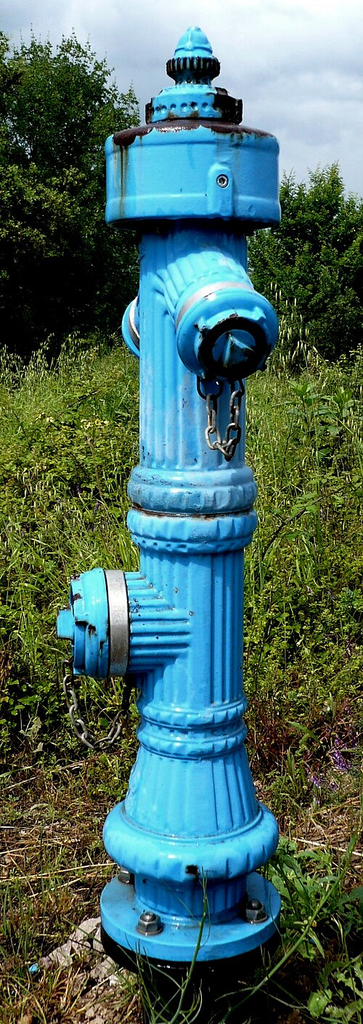

Hidran di Pulau Krk, Kroasia

### Contoh: irisan dua silinder yang sama besar

Di ruang afin $\mathbb A_K^3$ dengan $K=\mathbb R$, pertimbangkan kedua silinder

$$S_1=\{(x,y,z)\mid x^2+y^2=1\},
\qquad
S_2=\{(x,y,z)\mid y^2+z^2=1\}.$$

Keduanya merupakan himpunan tak tereduksi, sebagaimana akan kita lihat kelak untuk $K$ takhingga. Seperti apakah irisannya? Irisan tersebut dideskripsikan oleh ideal $\mathfrak a$ yang dibangkitkan oleh $X^2+Y^2-1$ dan $Y^2+Z^2-1$. Mengurangkan satu persamaan dari persamaan lainnya memberikan

$$X^2-Z^2=(X-Z)(X+Z)\in\mathfrak a.$$

Namun, kedua faktor tersebut sendiri tidak berada dalam $\mathfrak a$. Sebagai contoh, $(1,0,-1)$ merupakan titik irisan tempat $X-Z$ tidak lenyap (untuk karakteristik $\ne2$), sedangkan $(1,0,1)$ merupakan titik irisan tempat $X+Z$ tidak lenyap. Komponen-komponen irisan justru dideskripsikan oleh

$$\mathfrak b_1=\mathfrak a+(X-Z),
\qquad
\mathfrak b_2=\mathfrak a+(X+Z).$$

Keduanya ideal prima, dan gelanggang faktor yang pertama adalah

$$\begin{aligned}
K[X,Y,Z]/\mathfrak b_1
&=K[X,Y,Z]/(\mathfrak a+(X-Z))\\
&\cong K[X,Y]/(X^2+Y^2-1).
\end{aligned}$$

Untuk melihat isomorfisme terakhir, eliminasi $Z$ dengan persamaan $X-Z=0$; kedua persamaan silinder lalu menjadi identik. Argumen bagi ideal lainnya sama. Secara geometris, setiap titik $S_1\cap S_2$ terletak pada bidang

$$E_1=V(Z-X)
\qquad\text{atau}\qquad
E_2=V(Z+X).$$

Selain itu,

$$E_1\cap S_1=E_1\cap S_1\cap S_2=E_1\cap S_2,$$

dan demikian pula untuk $E_2$, sebab kedua persamaan silinder menjadi identik pada masing-masing bidang tersebut.

Seperti apakah irisan-irisan itu jika dilihat di dalam bidangnya? Pada $E_1$, gunakan koordinat $Y$ dan $U=Z+X$. Karena

$$X=\frac12((Z+X)-(Z-X)),$$

persamaan silinder pertama dapat ditulis

$$\left(\frac12((Z+X)-(Z-X))\right)^2+Y^2=1.$$

Di bidang $E_1$, tempat $Z=X$, persamaan ini menjadi

$$\left(\frac12U\right)^2+Y^2=1,$$

atau

$$\frac14U^2+Y^2=1.$$

Ini merupakan persamaan elips. Sebelumnya, perhitungan gelanggang faktor $K[X,Y,Z]/\mathfrak b_1$ menghasilkan persamaan lingkaran. Tidak ada pertentangan: lingkaran dan elips dapat diubah satu sama lain dengan transformasi linear, sehingga gelanggang faktornya isomorfik. Sebagai objek metrik, keduanya berbeda, dan irisan dua silinder ini terdiri atas dua elips. Transformasi variabel ortonormal mempertahankan struktur metrik, tetapi variabel $Y$, $X+Z$, dan $X-Z$ tidak mendefinisikan transformasi ortonormal.

Jadi,

$$S_1\cap S_2=V(\mathfrak b_1)\cup V(\mathfrak b_2),$$

dengan

$$\mathfrak b_1=(X^2+Y^2-1,X-Z),
\qquad
\mathfrak b_2=(X^2+Y^2-1,X+Z),$$

yang mendeskripsikan dua elips. Untuk menentukan bagaimana kedua elips ini beririsan, hitung jumlah idealnya:

$$\begin{aligned}
\mathfrak b_1+\mathfrak b_2
&=(X^2+Y^2-1,X-Z,X+Z)\\
&=(Y^2-1,X,Z).
\end{aligned}$$

Lokus nolnya terdiri atas dua titik $(0,1,0)$ dan $(0,-1,0)$.

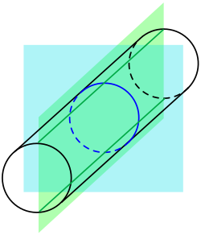

Arah utama pada sebuah silinder

## Banyaknya titik pada kurva

Kita telah melihat bahwa irisan sebuah kurva dengan sebuah garis hanya terdiri atas berhingga banyak titik, kecuali garis itu sendiri merupakan komponen kurva; lihat Lema 1.3. Sekarang kita akan memperluas hasil ini ke irisan dua kurva bidang sebarang. Kita memerlukan definisi berikut.

### Definisi: lapangan fungsi rasional

Misalkan $K$ suatu lapangan dan $K[X]$ gelanggang polinomial satu variabel di atas $K$. Lapangan pecahan $Q(K[X])$ disebut *lapangan fungsi rasional* di atas $K$ dan ditulis

$$K(X).$$

### Teorema: irisan kurva tanpa komponen bersama

Misalkan $K$ suatu lapangan dan

$$F,G\in K[X,Y]$$

dua polinom tanpa faktor persekutuan yang takkonstan. Maka hanya ada berhingga banyak titik $P_1,\ldots,P_n$ dalam $V(F,G)$.

#### Bukti

Pandang $F,G\in K[X,Y]$ sebagai unsur $K(X)[Y]$, dengan $K(X)$ lapangan fungsi rasional dalam $X$. Menurut Soal 4.27, $F$ dan $G$ juga tidak mempunyai faktor persekutuan dalam $K(X)[Y]$. Karena gelanggang ini merupakan domain ideal utama, keduanya bersama-sama membangkitkan ideal satuan. Jadi, terdapat

$$A,B\in K(X)[Y]$$

dengan

$$AF+BG=1.$$

Kalikan dengan penyebut persekutuan $A$ dan $B$. Di dalam $K[X,Y]$ diperoleh

$$\widetilde A F+\widetilde B G=H,
\qquad
0\ne H\in K[X].$$

Setiap akar bersama $F$ dan $G$ dalam $\mathbb A_K^2$ harus menjadi akar $H$. Dengan demikian, hanya ada berhingga banyak nilai $X$ yang mungkin muncul dalam akar bersama. Dengan menukar peran $X$ dan $Y$, diperoleh bahwa hanya ada berhingga banyak nilai $Y$ yang mungkin. Karena itu, jumlah akar bersama seluruhnya berhingga. $\square$

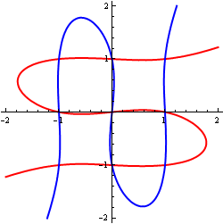

Dua kurva kubik

### Korolari: kurva prima dengan takhingga banyak titik

Misalkan $K$ suatu lapangan dan $F\in K[X,Y]$ suatu polinom prima. Andaikan kurva $V(F)$ mempunyai takhingga banyak titik. Maka ideal pelenyapan $V(F)$ sama dengan ideal utama $(F)$, dan $V(F)$ tak tereduksi.

#### Bukti

Jelas bahwa

$$(F)\subseteq\operatorname{Id}(V(F)).$$

Ambil $G\in\operatorname{Id}(V(F))$. Menurut Lema 3.8(3),

$$V(F)=V(\operatorname{Id}(V(F)))\subseteq V(F,G).$$

Jika $G$ bukan kelipatan $F$, Teorema 4.8 langsung memberikan pertentangan dengan asumsi bahwa $V(F)$ mempunyai takhingga banyak titik. Jadi,

$$\operatorname{Id}(V(F))=(F).$$

Ideal ini prima, dan oleh Lema 4.3, $V(F)$ tak tereduksi. $\square$

**Navigasi sumber:** mata kuliah - Kuliah 3 - Kuliah 5 (sumber) - Lembar Kerja 4

# Lembar Kerja 4

## Soal latihan

### Soal 4.1

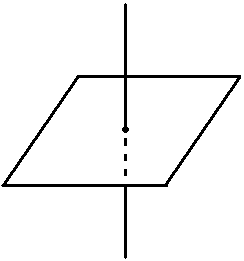

Sebuah permukaan dan garis tegak

Temukan suatu ideal yang lokus nolnya merupakan objek pada gambar di atas.

### Soal 4.2

Misalkan $V\subseteq\mathbb A_K^n$ suatu subhimpunan yang terdiri atas berhingga banyak titik. Buktikan bahwa $V$ tak tereduksi tepat ketika $V$ terdiri atas satu titik.

### Soal 4.3

Buat sketsa sebuah contoh subhimpunan aljabar afin yang terhubung tetapi tidak tak tereduksi.

### Soal 4.4

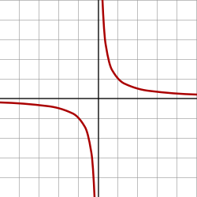

Hiperbola siku-siku

Tentukan komponen-komponen tak tereduksi dari hiperbola real tersebut.

### Soal 4.5

Misalkan $K$ suatu lapangan dengan karakteristik $\ne2$ dan $a\in K$ tidak nol. Buktikan bahwa polinom

$$X^2+Y^2+a\in K[X,Y]$$

tak tereduksi.

### Soal 4.6

Misalkan $K$ suatu lapangan dan

$$\mathfrak p=(p)\subseteq K[X]$$

suatu ideal prima. Buktikan bahwa lokus nol $V(\mathfrak p)\subseteq\mathbb A_K^1$ adalah seluruh $\mathbb A_K^1$ (yang ketaktereduksiannya bergantung pada lapangan) atau terdiri atas satu titik (dan karena itu tak tereduksi).

**Catatan edisi:** sebagaimana tertulis, pernyataan sumber tidak mencakup kasus $V(\mathfrak p)=\varnothing$, misalnya $K=\mathbb R$ dan $\mathfrak p=(X^2+1)$. Catatan ini tidak mengubah teks soal sumber.

### Soal 4.7

Misalkan $K$ suatu lapangan berhingga dan $\mathfrak p\subset K[X_1,\ldots,X_n]$ suatu ideal prima. Buktikan bahwa lokus nol

$$V(\mathfrak p)\subseteq\mathbb A_K^n$$

hanya dapat tak tereduksi jika terdiri atas satu titik.

### Soal 4.8

Buktikan bahwa polinom real

$$P=X^2(X-1)^2+Y^2\bigl(X^2+(X-1)^2\bigr)
\in\mathbb R[X,Y]$$

merupakan polinom prima, sedangkan lokus nol

$$V(P)\subseteq\mathbb R^2$$

takkosong tetapi tereduksi.

### Soal 4.9

Di $\mathbb A_{\mathbb R}^3$, hitung irisan silinder

$$V(x^2+y^2-1)$$

dengan bola berpusat di $P=(0,0,0)$ dan berjari-jari $r$, sebagai fungsi dari $r$. Kapan irisan tersebut kosong, dan kapan tak tereduksi?

Anda boleh menggunakan fakta bahwa lingkaran real tak tereduksi.

Soal berikut mengatakan bahwa irisan dua grafik polinom satu variabel sama secara aljabar, bukan hanya titik demi titik, dengan irisan grafik selisihnya dan sumbu $x$. Lihat juga Soal 26.3.

### Soal 4.10 ★

Misalkan $F,G\in K[X]$ polinom satu variabel di atas suatu lapangan $K$. Buktikan bahwa terdapat isomorfisme aljabar-$K$

$$K[X,Y]/(Y-F,Y-G)\cong K[X]/(F-G).$$

### Soal 4.11 ★

Misalkan dua lingkaran berbeda di bidang diberikan oleh persamaan lingkaran $F$ dan $G$.

1. Buktikan bahwa gelanggang faktor $K[X,Y]/(F,G)$ isomorfik dengan $K[X,Y]/(F,H)$, dengan $H$ berderajat paling tinggi $1$.
2. Buktikan bahwa $K[X,Y]/(F,G)$ isomorfik dengan suatu gelanggang berbentuk $K[U]/(Q)$, dengan $Q\in K[U]$ berderajat paling tinggi $2$.

### Soal 4.12 ★

Misalkan $R$ suatu gelanggang komutatif dan $R[X]$ gelanggang polinomial di atas $R$. Misalkan $\mathfrak a\subseteq R[X]$ ideal dengan pembangkit

$$\mathfrak a=(F_0,F_1,\ldots,F_n),$$

dengan $F_0=X-r$ untuk suatu $r\in R$. Untuk $i\ge1$, misalkan $G_i\in R$ diperoleh dari $F_i$ dengan mengganti $X$ oleh $r$. Buktikan isomorfisme gelanggang faktor

$$R[X]/\mathfrak a\cong R/(G_1,\ldots,G_n).$$

### Soal 4.13

Pertimbangkan himpunan bilangan real $\mathbb R$ dengan topologi metrik. Apakah $\mathbb R$ tak tereduksi?

### Soal 4.14 ★

Misalkan $p$ suatu bilangan prima dan $\mathbb Z/(p)$ lapangan hasil bagi yang bersesuaian. Buktikan bahwa setiap kuadrik berbentuk

$$F=aX^2+bY^2+c=0,
\qquad a,b\ne0,$$

mempunyai sekurang-kurangnya satu solusi dalam $\mathbb Z/(p)$.

### Soal 4.15 ★

Misalkan $\mathfrak a$ suatu ideal dalam gelanggang komutatif $R$. Buktikan bahwa $\mathfrak a$ merupakan ideal prima tepat ketika $\mathfrak a$ adalah kernel suatu homomorfisme gelanggang

$$\varphi:R\longrightarrow K$$

ke suatu lapangan $K$.

### Soal 4.16

Buktikan bahwa setiap ideal maksimal $\mathfrak m$ dalam gelanggang komutatif $R$ merupakan ideal prima.

### Soal 4.17 ★

Misalkan $R$ suatu gelanggang komutatif dan $\mathfrak p$ suatu ideal. Buktikan bahwa $\mathfrak p$ merupakan ideal prima tepat ketika gelanggang faktor $R/\mathfrak p$ merupakan domain integral.

### Soal 4.18

Misalkan $\mathfrak p\subseteq R$ suatu ideal prima dalam gelanggang komutatif $R$. Buktikan bahwa dari

$$\mathfrak a\cap\mathfrak b\subseteq\mathfrak p$$

mengikuti $\mathfrak a\subseteq\mathfrak p$ atau $\mathfrak b\subseteq\mathfrak p$.

### Soal 4.19

Misalkan $R$ dan $S$ gelanggang-gelanggang komutatif, $\varphi:R\to S$ suatu homomorfisme gelanggang, dan $\mathfrak p$ suatu ideal prima dalam $S$. Buktikan bahwa praimaj $\varphi^{-1}(\mathfrak p)$ merupakan ideal prima dalam $R$.

Berikan sebuah contoh yang menunjukkan bahwa praimaj suatu ideal maksimal tidak harus maksimal.

### Soal 4.20

Misalkan $K$ suatu lapangan dan $L=K(X)$ lapangan pecahan dari gelanggang polinomial $K[X]$. Buktikan bahwa terdapat takhingga banyak lapangan antara $K$ dan $L$.

### Soal 4.21

Jelaskan pada bagian mana bukti Teorema 4.8 gagal jika hendak diperluas ke lebih dari dua variabel.

### Soal 4.22

Misalkan $P(X)$ dan $Q(Y)$ polinom-polinom takkonstan dalam variabel yang ditunjukkan. Berikan suatu batas (di bawah syarat apa?) bagi banyaknya titik irisan kedua kurva

$$V(Y-P(X))
\qquad\text{dan}\qquad
V(X-Q(Y)).$$

Soal-soal berikut menggunakan istilah *pemetaan tertutup* dan *pemetaan terbuka*. Suatu pemetaan kontinu $f:X\to Y$ antara ruang-ruang topologis disebut *tertutup* apabila citra setiap himpunan tertutup kembali tertutup. Pemetaan tersebut disebut *terbuka* apabila citra setiap himpunan terbuka kembali terbuka.

### Soal 4.23

Buktikan bahwa proyeksi

$$\mathbb A_K^2\longrightarrow\mathbb A_K^1,
\qquad
(x,y)\longmapsto x,$$

bukan pemetaan tertutup dalam topologi Zariski.

### Soal 4.24

Buktikan bahwa suatu kurva aljabar bidang di atas bilangan kompleks $\mathbb C$ tidak kompak dalam topologi metrik.

## Soal untuk dikumpulkan

### Soal 4.25 - 6 poin

Misalkan $p\ge3$ suatu bilangan prima dan $K=\mathbb Z/(p)$ lapangan hasil bagi yang bersesuaian. Diberikan polinom

$$F=\alpha X^2+\beta XY+\gamma Y^2+\delta X+\epsilon Y+\eta
\in\mathbb Z/(p)[X,Y].$$

Jika $\alpha,\beta,\gamma$ tidak semuanya nol, polinom ini merupakan sebuah kuadrik. Buktikan bahwa tepat salah satu dari tiga alternatif berikut berlaku bagi lokus nol $V(F)\subseteq\mathbb A_K^2$.

1. $V(F)$ mempunyai sekurang-kurangnya satu titik.
2. $F=c$ untuk suatu konstanta $c\ne0$.
3. Ada suatu transformasi variabel sehingga, dalam koordinat baru, polinomnya berbentuk $Z^2-u$ dengan $u\in\mathbb Z/(p)$ suatu nonkuadrat.

**Petunjuk sumber:** Untuk satu kasus penting, Soal 9.20 dalam *Teori Bilangan (Osnabrück 2025)* berguna.

### Soal 4.26 - 3 poin

Misalkan $V$ suatu himpunan aljabar afin yang tak tereduksi dan mempunyai sekurang-kurangnya dua titik. Misalkan $P_1,\ldots,P_m\in V$ berhingga banyak titik. Buktikan bahwa

$$V\setminus\{P_1,\ldots,P_m\}$$

juga tak tereduksi dalam topologi terinduksi.

### Soal 4.27 - 4 poin

Misalkan $R$ suatu domain faktorisasi tunggal dengan lapangan pecahan $Q(R)$. Buktikan bahwa jika $F,G\in R[X]$ tidak mempunyai faktor persekutuan takkonstan, maka, ketika dipandang sebagai unsur $Q(R)[X]$, keduanya juga tidak mempunyai faktor persekutuan.

**Catatan sumber:** Anda boleh membatasi diri pada kasus bahwa $R$ merupakan domain ideal utama.

### Soal 4.28 - 3 poin

Misalkan $K=\mathbb Q$ lapangan bilangan rasional. Tentukan, dengan alasan, apakah

$$V(X^2+Y^2-1)\subseteq\mathbb A_{\mathbb Q}^2$$

tak tereduksi.

**Petunjuk sumber:** Gunakan Soal 1.28 tentang parametrisasi rasional lingkaran satuan dan Korolari 4.9.

### Soal 4.29 - 4 poin

Buktikan bahwa proyeksi

$$\mathbb A_K^2\longrightarrow\mathbb A_K^1,
\qquad
(x,y)\longmapsto x,$$

merupakan pemetaan terbuka dalam topologi Zariski.

### Soal 4.30 - 4 poin

Buktikan bahwa bidang afin $\mathbb A_K^2$ dengan topologi Zariski bersifat kompak.

**Navigasi sumber:** Kuliah 4 - solusi publik Unit 4 - Lembar Kerja 3 - Lembar Kerja 5 (sumber)

# Solusi Publik Lembar Kerja 4

Sumber hanya menyediakan solusi publik bagi Soal 4.10, 4.11, 4.12, 4.14, 4.15, dan 4.17 pada batas revisi yang dibekukan. Tidak ada solusi tambahan yang dibuat untuk edisi ini.

## Solusi Soal 4.10

Kita akan membuktikan isomorfisme

$$K[X,Y]/(Y-F,Y-G)\cong K[X]/(F-G).$$

Pertimbangkan homomorfisme aljabar-$K$

$$\varphi:K[X,Y]\longrightarrow K[X]/(F-G)$$

yang memetakan $X\mapsto X$ dan $Y\mapsto F$. Berlaku

$$\varphi(Y-F)=F-F=0$$

dan

$$\varphi(Y-G)=F-G=0.$$

Menurut teorema homomorfisme bagi gelanggang, diperoleh homomorfisme aljabar-$K$ terinduksi

$$\overline\varphi:
K[X,Y]/(Y-F,Y-G)\longrightarrow K[X]/(F-G).$$

Sekarang pertimbangkan homomorfisme aljabar-$K$

$$\psi:K[X]\longrightarrow K[X,Y]/(Y-F,Y-G)$$

dengan $X\mapsto X$. Di gelanggang sasaran,

$$\psi(F-G)=F-G=(Y-G)-(Y-F)=0.$$

Karena itu diperoleh homomorfisme terinduksi

$$\overline\psi:
K[X]/(F-G)\longrightarrow K[X,Y]/(Y-F,Y-G).$$

Kedua komposisi $\overline\psi\circ\overline\varphi$ dan $\overline\varphi\circ\overline\psi$ masing-masing merupakan identitas.

Kembali ke Soal 4.10.

## Solusi Soal 4.11

1. Persamaan sebuah lingkaran berbentuk

   $$(X-a)^2+(Y-b)^2-c=0.$$

   Setelah dikembangkan, tulis

   $$F=X^2+Y^2+rX+sY+t$$

   dan, dengan cara yang sama,

   $$G=X^2+Y^2+\widetilde rX+\widetilde sY+\widetilde t.$$

   Maka

   $$H=F-G=(r-\widetilde r)X+(s-\widetilde s)Y
   +(t-\widetilde t).$$

   Karena kedua lingkaran berbeda, $H$ berderajat $1$ atau $0$. Selain itu,

   $$(F,G)=(F,H),$$

   sehingga gelanggang faktornya isomorfik.
2. Gunakan deskripsi pada bagian pertama:

   $$R=K[X,Y]/(F,H).$$

   Jika $H$ suatu konstanta taknol, $R$ adalah gelanggang nol. Selain itu, $H$ linear, sehingga salah satu variabel dapat dinyatakan dalam variabel lainnya; katakan

   $$Y=\alpha X+\beta.$$

   Dengan demikian,

   $$\begin{aligned}
   K[X,Y]/(F,H)
   &\cong K[X,Y]/(X^2+Y^2+rX+sY+t,\,Y-\alpha X-\beta)\\
   &\cong K[X]/\bigl(X^2+(\alpha X+\beta)^2+rX
   +s(\alpha X+\beta)+t\bigr)\\
   &\cong K[X]/(uX^2+vX+w).
   \end{aligned}$$

Kembali ke Soal 4.11.

## Solusi Soal 4.12

Pertimbangkan homomorfisme evaluasi yang surjektif

$$R[X]\longrightarrow R/(G_1,\ldots,G_n),
\qquad
X\longmapsto[r].$$

Pembangkit $F_0=X-r$ dipetakan ke $0$, dan untuk $i\ge1$, pembangkit $F_i$ dipetakan ke $G_i=0$. Teorema homomorfisme memberikan homomorfisme gelanggang surjektif

$$\varphi:R[X]/\mathfrak a\longrightarrow R/(G_1,\ldots,G_n).$$

Kita tinggal membuktikan bahwa homomorfisme ini injektif. Misalkan

$$P=a_0+a_1X+\cdots+a_mX^m\in R[X]$$

dipetakan oleh $\varphi$ ke $0$. Ini berarti

$$P(r)=a_0+a_1r+\cdots+a_mr^m
\in(G_1,\ldots,G_n)$$

di dalam $R$. Selanjutnya,

$$\begin{aligned}
P-P(r)
&=\sum_{i=0}^m a_iX^i-\sum_{i=0}^m a_ir^i\\
&=\sum_{i=0}^m a_i(X^i-r^i)\\
&=\sum_{i=1}^m a_i(X^i-r^i)\\
&=\sum_{i=1}^m (X-r)H_i,
\end{aligned}$$

sebab $X^i-r^i$ selalu habis dibagi $X-r$. Maka

$$P-P(r)\in(X-r),$$

dan secara keseluruhan

$$P\in(X-r,G_1,\ldots,G_n).$$

Untuk unsur-unsur tertentu $B_i$ juga berlaku

$$F_i-G_i=F_i-F_i(r)=(X-r)B_i.$$

Karena itu,

$$\begin{aligned}
P&\in(X-r,G_1,\ldots,G_n)\\
&=(X-r,F_1,\ldots,F_n)\\
&=\mathfrak a.
\end{aligned}$$

Jadi, $\varphi$ injektif dan merupakan isomorfisme yang diminta.

Kembali ke Soal 4.12.

## Solusi Soal 4.14

Untuk $p=2$, pernyataan dapat diperiksa langsung. Andaikan $p\ge3$. Tulis persamaan sebagai

$$aX^2=-bY^2-c.$$

Karena $a$ dan $b$ merupakan unit, teorema tentang banyaknya residu kuadrat menunjukkan bahwa himpunan nilai di ruas kiri maupun himpunan nilai di ruas kanan masing-masing mempunyai $(p+1)/2$ unsur. Lapangan $\mathbb Z/(p)$ hanya mempunyai $p$ unsur, sehingga kedua himpunan itu tidak mungkin saling lepas. Jadi, terdapat $d\in\mathbb Z/(p)$ yang dapat ditulis sebagai

$$d=aX^2=-bY^2-c$$

untuk unsur-unsur tertentu $X,Y\in\mathbb Z/(p)$. Pasangan tersebut merupakan solusi persamaan semula.

Kembali ke Soal 4.14.

## Solusi Soal 4.15

Mula-mula misalkan $\mathfrak a$ suatu ideal prima. Maka gelanggang faktor $R/\mathfrak a$ merupakan domain integral, sehingga mempunyai lapangan pecahan $Q(R/\mathfrak a)$. Komposisi proyeksi kanonik dengan inklusi ke lapangan pecahan,

$$\varphi:R\longrightarrow Q(R/\mathfrak a),
\qquad
x\longmapsto[x],$$

merupakan homomorfisme gelanggang ke suatu lapangan dengan

$$\ker\varphi=\mathfrak a.$$

Sebaliknya, kernel suatu homomorfisme gelanggang

$$\varphi:R\longrightarrow K$$

selalu merupakan ideal. Jika $ab\in\ker\varphi$, maka

$$0=\varphi(ab)=\varphi(a)\varphi(b).$$

Karena lapangan $K$ tidak mempunyai pembagi nol, berlaku $\varphi(a)=0$ atau $\varphi(b)=0$. Ini setara dengan $a\in\ker\varphi$ atau $b\in\ker\varphi$. Jadi, $\ker\varphi$ merupakan ideal prima.

Kembali ke Soal 4.15.

## Solusi Soal 4.17

Mula-mula misalkan $\mathfrak p$ suatu ideal prima. Khususnya, $\mathfrak p\subsetneq R$, sehingga $R/\mathfrak p$ bukan gelanggang nol. Andaikan $fg=0$ dalam $R/\mathfrak p$, dengan $f$ dan $g$ diwakili oleh unsur dalam $R$. Maka $fg\in\mathfrak p$, sehingga $f\in\mathfrak p$ atau $g\in\mathfrak p$. Dalam $R/\mathfrak p$, ini tepat berarti $f=0$ atau $g=0$. Jadi, $R/\mathfrak p$ merupakan domain integral.

Sebaliknya, andaikan $R/\mathfrak p$ suatu domain integral. Gelanggang hasil bagi ini bukan gelanggang nol, sehingga $\mathfrak p\ne R$. Jika $f,g\notin\mathfrak p$, maka kelas $f$ dan $g$ keduanya tidak nol dalam $R/\mathfrak p$. Karena gelanggang itu merupakan domain integral, hasil kalinya tidak nol. Jadi,

$$fg\notin\mathfrak p.$$

Kontraposisi menyatakan bahwa $fg\in\mathfrak p$ memaksa $f\in\mathfrak p$ atau $g\in\mathfrak p$. Maka $\mathfrak p$ merupakan ideal prima.

Kembali ke Soal 4.17.

# Kuliah 5: Komponen Homogen, Normalisasi Noether, dan Pemetaan Polinomial

## Komponen homogen

Kita membahas derajat dan dekomposisi polinom dalam beberapa variabel menjadi komponen-komponen homogen.

### Definisi: derajat

Misalkan $S$ suatu gelanggang komutatif dan

$$R=S[X_1,\ldots,X_n]$$

gelanggang polinomial dalam $n$ variabel di atas $S$. Untuk suatu monomial

$$G=X^\nu=X_1^{\nu_1}\cdots X_n^{\nu_n},$$

bilangan

$$|\nu|=\sum_{j=1}^n\nu_j$$

disebut *derajat* $G$. Untuk polinom taknol

$$F=\sum_\nu a_\nu X^\nu,$$

bilangan

$$\max\{|\nu|:a_\nu\ne0\}$$

disebut *derajat* $F$.

### Definisi: dekomposisi homogen

Misalkan $S$ dan $R=S[X_1,\ldots,X_n]$ seperti di atas. Untuk suatu polinom

$$F=\sum_\nu a_\nu X^\nu\in R,$$

dekomposisi

$$F=\sum_{i=0}^d F_i,$$

dengan

$$F_i=\sum_{\substack{\nu\\|\nu|=i}}a_\nu X^\nu,$$

disebut *dekomposisi homogen* dari $F$. Polinom $F_i$ disebut *komponen homogen* dari $F$ yang berderajat $i$. Polinom $F$ sendiri disebut *homogen* apabila dekomposisi homogennya hanya mempunyai satu komponen taknol.

[figure not shown]

Sebuah kerucut (himpunan nol dari polinom homogen)

Himpunan nol suatu polinom homogen $F$ merupakan kerucut garis melalui titik asal: jika suatu titik $P$ berada dalam $V(F)$, maka seluruh garis melalui $P$ dan $0$ juga berada dalam $V(F)$.

### Contoh: derajat total dan derajat terhadap satu variabel

Polinom

$$F=4X^3YZ^2+2X^2Y^5+5XYZ^7-3X^4YZ^4+X^8-Y^7+2Y^6Z^3+X+5$$

berderajat $9$, dengan komponen-komponen homogen

$$F_9=5XYZ^7-3X^4YZ^4+2Y^6Z^3,$$

$$F_8=X^8,$$

$$F_7=2X^2Y^5-Y^7,$$

$$F_6=4X^3YZ^2,$$

$$F_5=F_4=F_3=F_2=0,$$

serta

$$F_1=X,
\qquad
F_0=5.$$

Jika $F$ dipandang sebagai polinom dalam $(K[Y,Z])[X]$ dan kita hanya memperhatikan pangkat $X$, kita berbicara tentang *derajat-$X$*. Derajat-$X$ dari $F$ adalah $8$. Ada pula dekomposisi homogen terhadap gradasi-$X$: komponen berderajat-$X$ nol adalah

$$-Y^7+2Y^6Z^3+5,$$

sedangkan komponen berderajat-$X$ satu adalah

$$5XYZ^7+X.$$

## Banyaknya titik pada kurva II

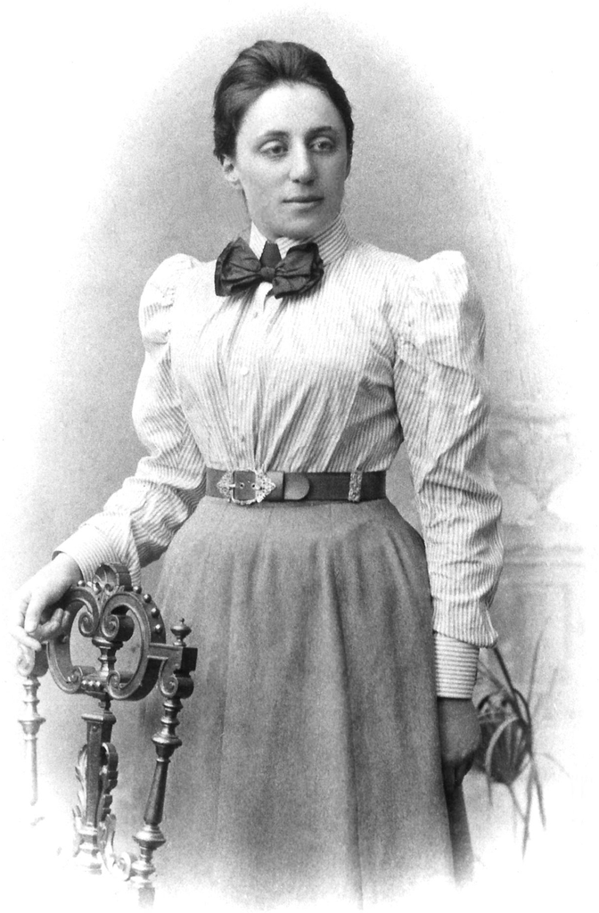

Emmy Noether (1882-1935)

Teorema berikut disebut teorema *normalisasi Noether* dalam kasus kurva bidang.

### Teorema: normalisasi Noether untuk kurva bidang

Misalkan $K$ suatu lapangan tertutup secara aljabar dan $F\in K[X,Y]$ suatu polinom takkonstan berderajat $d$ yang mendefinisikan kurva aljabar

$$C=V(F).$$

Terdapat suatu transformasi koordinat linear sedemikian sehingga, dalam koordinat baru $\widetilde X,\widetilde Y$, polinom yang ditransformasikan mempunyai bentuk

$$\widetilde F=\widetilde X^d+\text{suku-suku berderajat lebih rendah dalam }\widetilde X.$$

#### Bukti

Tuliskan dekomposisi homogen

$$F=F_d+F_{d-1}+\cdots+F_1+F_0,$$

dengan

$$F_i=\sum_{a+b=i}c_{a,b}X^aY^b.$$

Polinom homogen dalam dua variabel mempunyai sifat faktorisasi yang sama dengan polinom dalam satu variabel. Karena $K$ tertutup secara aljabar, terdapat faktorisasi

$$F_d=c(Y-e_1X)\cdots(Y-e_kX)X^{d-k}.$$

Karena $c$ mempunyai akar ke-$d$, dengan menskalakan variabel kita dapat mengandaikan $c=1$. Lapangan $K$ khususnya takhingga, sehingga kita dapat memilih $e\in K$ yang berbeda dari semua $e_j$. Gunakan koordinat baru

$$\widetilde Y=Y-eX,
\qquad
\widetilde X=X.$$

Dalam koordinat ini, setiap faktor linear menjadi

$$\begin{aligned}
Y-e_jX
&=Y-eX+eX-e_jX\\
&=\widetilde Y-(e_j-e)X\\
&=\widetilde Y-(e_j-e)\widetilde X,
\end{aligned}$$

dengan $e_j-e\ne0$, sedangkan faktor $X$ menjadi $\widetilde X$. Setelah dikalikan, $\widetilde X^d$ muncul dengan koefisien taknol di $K$, yang sekali lagi dapat dibuat sama dengan $1$ melalui penskalaan. Karena komponen homogen berderajat lebih rendah tetap mempertahankan derajatnya, semua monomial lain mempunyai derajat-$\widetilde X$ paling tinggi $d-1$. $\square$

### Korolari: kurva bidang mempunyai takhingga banyak titik

Misalkan $K$ suatu lapangan tertutup secara aljabar dan $F\in K[X,Y]$ suatu polinom takkonstan yang mendefinisikan kurva aljabar $C=V(F)$. Maka $C$ mempunyai takhingga banyak elemen.

#### Bukti

Menurut teorema normalisasi Noether, kita dapat mengandaikan

$$F=X^d+P_{d-1}(Y)X^{d-1}+\cdots+P_1(Y)X+P_0(Y),$$

dengan $P_i(Y)\in K[Y]$. Untuk setiap nilai $a\in K$ yang diberikan bagi $Y$, substitusi $Y=a$ menghasilkan polinom monik berderajat $d$ dalam $X$. Karena $K$ tertutup secara aljabar, polinom itu mempunyai sedikitnya satu akar $b\in K$. Jadi titik dengan koordinat $X=b$ dan $Y=a$ berada pada $C$. Karena $K$ takhingga, kurva tersebut mempunyai takhingga banyak titik. $\square$

**Catatan edisi:** setelah menetapkan $Y=a$ dan memilih akar $X=b$, sumber menulis pasangan titik sebagai $(a,b)$. Edisi ini menyebut kedua koordinat secara eksplisit agar urutannya tetap $X=b$, $Y=a$.

## Pemetaan polinomial antara ruang-ruang afin

Pertimbangkan pemetaan

$$\begin{aligned}
\varphi:\mathbb A_K^r&\longrightarrow\mathbb A_K^n,\\
(t_1,\ldots,t_r)&\longmapsto
(\varphi_1(t_1,\ldots,t_r),\ldots,\varphi_n(t_1,\ldots,t_r))
=(x_1,\ldots,x_n),
\end{aligned}$$

dengan setiap fungsi komponen $\varphi_i\in K[T_1,\ldots,T_r]$. Jadi, setiap komponen pemetaan diberikan oleh suatu polinom dalam $r$ variabel. Kasus $n=1$ adalah sebuah polinom dalam $r$ variabel; kasus $r=1$ dan $n=2$ adalah parametrisasi kurva aljabar. Kelak kita akan mendefinisikan morfisme antara himpunan-himpunan aljabar afin dengan generalisasi yang lebih luas.

**Catatan edisi:** sumber mencetak gelanggang fungsi komponen sebagai $K[X_1,\ldots,X_r]$, walaupun parameter pemetaan dan gelanggang sasaran homomorfisme substitusinya memakai $T_1,\ldots,T_r$. Edisi ini menggunakan $K[T_1,\ldots,T_r]$ secara konsisten.

Suatu pemetaan polinomial $\varphi:\mathbb A_K^r\to\mathbb A_K^n$ menginduksi homomorfisme aljabar-$K$ antara gelanggang polinomial dalam arah berlawanan. Homomorfisme substitusi itu ditentukan oleh $X_i\mapsto\varphi_i$ dan ditulis

$$\begin{aligned}
\widetilde\varphi:
K[X_1,\ldots,X_n]&\longrightarrow K[T_1,\ldots,T_r],\\
F&\longmapsto F\circ\varphi
=F(\varphi_i/X_i).
\end{aligned}$$

Notasi $\varphi_i/X_i$ berarti mengganti variabel $X_i$ dengan $\varphi_i$. Dipandang sebagai fungsi, $F\circ\varphi$ adalah komposisi

$$\mathbb A_K^r\xrightarrow{\varphi}\mathbb A_K^n
\xrightarrow{F}\mathbb A_K^1.$$

Untuk lokus nol $V(F)\subseteq\mathbb A_K^n$ berlaku

$$\varphi^{-1}(V(F))=V(\widetilde\varphi(F)).$$

Selain pemetaan konstan, pemetaan polinomial yang paling sederhana adalah pemetaan afin-linear, yaitu pemetaan yang fungsi-fungsi komponennya merupakan polinom afin-linear:

$$\varphi_i=a_{i1}T_1+\cdots+a_{ir}T_r+c_i.$$

Pemetaan ini tidak harus linear karena titik asal tidak harus dipetakan ke titik asal; translasi diperbolehkan. Pemetaan afin-linear merupakan komposisi pemetaan linear dan translasi. Untuk $r=n$, suatu pemetaan afin-linear yang bijektif dipandang sebagai transformasi koordinat atau transformasi variabel.

### Definisi: transformasi variabel afin-linear

Misalkan $K$ suatu lapangan. Suatu pemetaan $\varphi:\mathbb A_K^n\to\mathbb A_K^n$ berbentuk

$$\varphi(x_1,\ldots,x_n)
=M
\begin{pmatrix}
x_1\\
\vdots\\
x_n
\end{pmatrix}
+(v_1,\ldots,v_n),$$

dengan $M$ suatu matriks invertibel, disebut *transformasi variabel afin-linear*.

Orang dapat memperdebatkan apakah transformasi variabel linear benar-benar memindahkan sesuatu di ruang atau hanya mengubah koordinat. Bagaimanapun, transformasi demikian merupakan alat penting untuk membawa polinom, sistem persamaan aljabar, atau himpunan aljabar afin ke bentuk yang lebih sederhana. Di bawah transformasi variabel, himpunan

$$V=V(F_1,\ldots,F_m)$$

berubah menjadi

$$\widetilde V=V(\widetilde F_1,\ldots,\widetilde F_m),
\qquad
\widetilde F_i=\widetilde\varphi(F_i),$$

dan $\widetilde V$ adalah prapeta $V$ di bawah $\varphi$.

### Definisi: ekuivalensi afin-linear

Dua himpunan aljabar afin

$$V,\widetilde V\subseteq\mathbb A_K^n$$

disebut *ekuivalen afin-linear* apabila terdapat transformasi variabel afin-linear $\varphi:\mathbb A_K^n\to\mathbb A_K^n$ sedemikian sehingga

$$\varphi^{-1}(V)=\widetilde V.$$

Konsep ini bergantung pada bagaimana situasi tersebut tertanam. Kelak kita akan melihat bahwa parabola dan garis di bidang saling isomorfik karena keduanya isomorfik dengan garis afin, tetapi keduanya tidak ekuivalen secara afin-linear.

Sifat-sifat aljabar dan topologis yang esensial dari suatu himpunan aljabar afin tetap terpelihara di bawah transformasi variabel afin-linear, termasuk ketaktereduksian, singularitas, perpotongan, keterhubungan, dan kekompakan. Sebaliknya, sifat-sifat khas geometri metrik real dapat berubah: sudut, panjang dan perbandingan panjang, volume, serta bentuk. Konsep-konsep terakhir itu tidak relevan bagi geometri aljabar. Karena itu, mulai sekarang kita akan mengubah suatu situasi ke bentuk yang diinginkan tanpa banyak penekanan jika transformasi semacam itu tersedia.

### Teorema: gelanggang faktor di bawah ekuivalensi afin-linear

Misalkan $K$ suatu lapangan dan $V,\widetilde V\subseteq\mathbb A_K^n$ dua himpunan aljabar afin yang ekuivalen afin-linear. Misalkan $\operatorname{Id}(V)$ dan $\operatorname{Id}(\widetilde V)$ ideal-ideal pelenyapan yang bersesuaian. Maka terdapat isomorfisme aljabar-$K$

$$K[X_1,\ldots,X_n]/\operatorname{Id}(V)
\cong
K[X_1,\ldots,X_n]/\operatorname{Id}(\widetilde V).$$

#### Bukti

Menurut definisi, terdapat transformasi variabel afin-linear

$$\mathbb A_K^n\longrightarrow\mathbb A_K^n,
\qquad
P\longmapsto\varphi(P),$$

dengan $\varphi^{-1}(V)=\widetilde V$. Misalkan $\widetilde\varphi$ automorfisme yang bersesuaian dari $K[X_1,\ldots,X_n]$. Maka

$$\widetilde\varphi^{-1}\bigl(\operatorname{Id}(\widetilde V)\bigr)
=\operatorname{Id}(V).$$

Teorema isomorfisme menghasilkan isomorfisme kedua gelanggang faktor. $\square$

### Catatan: gelanggang koordinat sebagai invarian intrinsik

Teorema sebelumnya mengungkapkan suatu prinsip penting dalam geometri aljabar: objek aljabar yang melekat pada suatu lokus nol adalah gelanggang faktor gelanggang polinomial oleh ideal pelenyapannya. Objek ini merupakan *invarian intrinsik* dari lokus nol, yaitu tidak bergantung pada penanamannya.

Dari sudut pandang ini, normalisasi Noether untuk kurva bidang memperoleh makna baru. Kita dapat mengandaikan persamaan kurva berbentuk

$$F=X^d+P_{d-1}(Y)X^{d-1}+\cdots+P_1(Y)X+P_0(Y).$$

Persamaan $F=0$ merupakan persamaan integral bagi kelas residu $X$. Lebih tepatnya, kelas residu $X$ dalam $K[X,Y]/(F)$ integral atas $K[Y]$. Karena $X$ membangkitkan gelanggang itu sebagai aljabar atas $K[Y]$, terdapat perluasan gelanggang integral, bahkan hingga,

$$K[Y]\longrightarrow
K[X,Y]/\bigl(X^d+P_{d-1}(Y)X^{d-1}+\cdots+P_1(Y)X+P_0(Y)\bigr).$$

Dengan demikian, teorema normalisasi Noether juga mengatakan bahwa, untuk setiap kurva aljabar di atas lapangan tertutup secara aljabar, gelanggang koordinatnya dapat direalisasikan sebagai perluasan hingga dari domain ideal utama $K[Y]$. Ini merupakan analogi langsung dengan gelanggang bilangan bulat dalam teori bilangan, yang juga merupakan perluasan hingga di atas domain ideal utama $\mathbb Z$.

Pemetaan polinomial umum antara ruang-ruang afin, berbeda dengan transformasi afin-linear, dapat mengubah banyak sifat aljabar: dimensi dapat berubah, singularitas dapat muncul, dan sebagainya. Namun, ketaktereduksian berpindah ke penutupan Zariski dari citra pemetaan.

### Teorema: penutupan citra pemetaan polinomial tak tereduksi

Misalkan $K$ suatu lapangan takhingga dan

$$\varphi:\mathbb A_K^r\longrightarrow\mathbb A_K^n$$

suatu pemetaan yang diberikan oleh $n$ polinom dalam $r$ variabel. Maka penutupan Zariski dari citra $\varphi$ tak tereduksi.

#### Bukti

Misalkan

$$B=\varphi(\mathbb A_K^r)$$

citra pemetaan. Menurut Lema 3.10,

$$\overline B=V(\operatorname{Id}(B)).$$

Untuk $P=\varphi(Q)$ dengan $Q\in\mathbb A_K^r$ dan $F\in K[X_1,\ldots,X_n]$ berlaku

$$F(P)=F(\varphi(Q))=(F\circ\varphi)(Q),$$

dengan $F\circ\varphi\in K[T_1,\ldots,T_r]$ diperoleh dengan mengganti $X_i$ oleh fungsi komponen ke-$i$, yaitu $\varphi_i\in K[T_1,\ldots,T_r]$. Karena itu, $F$ lenyap di seluruh $B$ tepat ketika $F\circ\varphi$ lenyap di seluruh $\mathbb A_K^r$. Karena $K$ takhingga, kondisi terakhir berarti bahwa $F\circ\varphi$ adalah polinom nol.

Jadi,

$$F\in\operatorname{Id}(B)$$

tepat ketika $F$ dipetakan ke nol oleh homomorfisme

$$\widetilde\varphi:
K[X_1,\ldots,X_n]\longrightarrow K[T_1,\ldots,T_r].$$

Dengan demikian, $\operatorname{Id}(B)$ adalah prapeta ideal prima, yakni ideal nol di $K[T_1,\ldots,T_r]$, dan karena itu sendiri merupakan ideal prima menurut Soal 4.19. Lema 4.3 kemudian menunjukkan bahwa $V(\operatorname{Id}(B))$ tak tereduksi. $\square$

# Lembar Kerja 5

## Soal latihan

### Soal 5.1

Misalkan $F\in K[X_1,\ldots,X_n]$ suatu polinom homogen dengan lokus nol $V(F)$. Buktikan bahwa bagi setiap titik $P\in V(F)$ dan setiap skalar $\lambda\in K$, berlaku pula $\lambda P\in V(F)$.

### Soal 5.2

Tentukan faktorisasi polinom

$$X^n-Y^n\in\mathbb C[X,Y]$$

untuk $n\in\mathbb N_+$.

### Soal 5.3 ★

Misalkan $K$ suatu lapangan tertutup secara aljabar dan $F\in K[X,Y]$ suatu polinom homogen. Buktikan bahwa $F$ terurai menjadi faktor-faktor linear.

### Soal 5.4

Misalkan $K$ suatu lapangan, $F\in K[X_1,\ldots,X_n]$ suatu polinom homogen, dan $F=GH$ suatu faktorisasi. Buktikan bahwa $G$ dan $H$ juga homogen.

### Soal 5.5

Misalkan $R$ suatu gelanggang komutatif dan

$$P=R[X_1,\ldots,X_m]$$

gelanggang polinomial di atas $R$ dalam $m$ variabel. Misalkan

$$\mathfrak m=(X_1,\ldots,X_m)$$

ideal yang dibangkitkan oleh variabel-variabel tersebut. Buktikan bahwa

$$\mathfrak m^n=P_{\ge n},$$

dengan $P_{\ge n}$ menyatakan ideal dalam $P$ yang dibangkitkan oleh semua polinom homogen berderajat $\ge n$.

### Soal 5.6

Buktikan bahwa suatu polinom homogen tetap homogen dengan derajat yang sama di bawah transformasi variabel linear, sedangkan hal ini tidak harus berlaku di bawah transformasi variabel afin-linear.

### Soal 5.7

Buktikan bahwa relasi ekuivalensi afin-linear merupakan suatu relasi ekuivalensi pada himpunan-himpunan aljabar afin $V,V'\subseteq\mathbb A_K^n$.

### Soal 5.8

Misalkan $P=(a,b)$ suatu titik di bidang afin, dan $L$ serta $L'$ dua garis berbeda yang melalui $P$. Misalkan $C=V(F)$, dengan $F\in K[X,Y]$, suatu kurva aljabar bidang. Deskripsikan secara eksplisit suatu transformasi variabel (perubahan koordinat) sedemikian sehingga dalam koordinat baru $P$ menjadi titik asal dan kedua garis menjadi kedua sumbu koordinat. Bagaimana persamaan kurva tersebut dalam koordinat baru?

### Soal 5.9

Misalkan $C$ dan $D$ masing-masing merupakan kurva aljabar afin bidang yang terdiri atas gabungan tiga garis berbeda, dan ketiga garis pada masing-masing kurva berpotongan di satu titik. Buktikan bahwa terdapat perubahan koordinat afin-linear yang memetakan $C$ ke $D$.